In questo lavoro analizziamo il fenomeno del churn in un’azienda di telecomunicazioni. Il dataset è suddiviso in cinque file e raccoglie informazioni su 7043 clienti, comprendendo variabili relative a dati demografici, tipologie di servizi sottoscritti, modalità di pagamento e storici contrattuali. L’obiettivo principale è comprendere i fattori che portano un cliente a lasciare il servizio al fine di prevedere ed intercettare tali situazioni.

# **Data Exploration e Preprocessing**

Per lo sviluppo di questo progetto preferiamo creare un dataset contenente tutti gli attributi che potranno favorire una migliore classificazione, utilizzando ogni file reperito sul sito di IBM, piuttosto di usare il dataset preprocessato disponibile su Kaggle.

```python
import os
from pathlib import Path
import pandas as pd
import numpy as np
import matplotlib.pyplot as plt
import seaborn as sns
from matplotlib.gridspec import GridSpec
from scipy.stats import gaussian_kde
import re
from sklearn.decomposition import PCA
from sklearn.preprocessing import StandardScaler
```

Precederemo caricando i files da utilizzare, fornendo una breve descrizione per ciascun attriibuto.

```python
file1_path = 'sample_data/CustomerChurn.xlsx'
file2_path = 'sample_data/Telco_customer_churn_demographics.xlsx'
file3_path = 'sample_data/Telco_customer_churn.xlsx'
file4_path = 'sample_data/Telco_customer_churn_services.xlsx'
file5_path = 'sample_data/Telco_customer_churn_status.xlsx'
```

Non sono presenti i files "Telco_customer_churn_location.xlsx" e "Telco_customer_churn_poppulation.xlsx". Le colonne contenute nel primo dataset menzionato sono già presenti in "Telco_customer_churn.xlsx", mentre il "Telco_customer_churn_population.xlsx" non risulta particolarmente informativo.

Visualizziamo il primo file

```python
df1 = pd.read_excel(file1_path)

df1 = df1.sort_values(by="Customer ID").reset_index(drop=True)
df1.head()
```

|  | LoyaltyID | Customer ID | Senior Citizen | Partner | Dependents | Tenure | Phone Service | Multiple Lines | Internet Service | Online Security | ... | Device Protection | Tech Support | Streaming TV | Streaming Movies | Contract | Paperless Billing | Payment Method | Monthly Charges | Total Charges | Churn |
| --- | --- | --- | --- | --- | --- | --- | --- | --- | --- | --- | --- | --- | --- | --- | --- | --- | --- | --- | --- | --- | --- |
| 0 | 200315 | 0002-ORFBO | No | Yes | Yes | 9 | Yes | No | DSL | No | ... | No | Yes | Yes | No | One year | Yes | Mailed check | 65.6 | 593.3 | No |
| 1 | 278817 | 0003-MKNFE | No | No | No | 9 | Yes | Yes | DSL | No | ... | No | No | No | Yes | Month-to-month | No | Mailed check | 59.9 | 542.4 | No |
| 2 | 192691 | 0004-TLHLJ | No | No | No | 4 | Yes | No | Fiber optic | No | ... | Yes | No | No | No | Month-to-month | Yes | Electronic check | 73.9 | 280.85 | Yes |
| 3 | 318845 | 0011-IGKFF | Yes | Yes | No | 13 | Yes | No | Fiber optic | No | ... | Yes | No | Yes | Yes | Month-to-month | Yes | Electronic check | 98.0 | 1237.85 | Yes |
| 4 | 508649 | 0013-EXCHZ | Yes | Yes | No | 3 | Yes | No | Fiber optic | No | ... | No | Yes | Yes | No | Month-to-month | Yes | Mailed check | 83.9 | 267.4 | Yes |

5 rows × 21 columns

Forniamo una panoramica degli attributi:

1. Customer ID | Nominale
   - È l'identificativo univoco del cliente.
2. LoyaltyID | Nominale
   - È l'identificativo univoco del programma fedeltà.
   - Serve a tracciare l’appartenenza a programmi promozionali.
3. Senior Citizen | Ordinale
   - Indica se un cliente ha un'età maggiore o uguale di 65 anni.
   - Probabilmente a causa del fatto che gli adulti over 65 hanno pattern di churn differenti.
4. Partner | Nominale
   - Indica se il cliente ha un partner.
   - Serve per effettuare un'analisi demografica famigliare.
5. Dependents | Nominale
   - Indica se un cliente ha persone a carico.
   - Serve per effettuare un'analisi demografica famigliare.
   - Probabilmente impatta sul tipo di servizi sottoscritti.
6. Tenure | Rapporto
   - Tiene traccia dei mesi di permanenza attiva.
   - Serve per misurare la fedeltà di un cliente.
   - Sarà uno dei predittori chiave del churn.
7. Phone Service | Nominale
   - Indica se un cliente ha un servizio telefonico attivo.
   - Differenzia i tipi di servizi o pacchetti acquistati.
8. Multiple Lines | Nominale
   - Indica se il cliente ha ulteriori linee telefoniche.
   - Avere più linee riduce il churn.
9. Internet Service | Nominale
   - Indica il tipo di connessione (No/DSL/Fiber Optic/Cable).
   - Affidabilità e costi variano con il servizio.
10. Online Security | Nominale
    - Indica se un cliente ha attivato la protezione antivirus/firewall.
    - Avere attivo un servizio diminuisce il churn.
11. Online Backup | Nominale
    - Indica se un cliente ha attivato il servizio di backup online.
    - Avere attivo un servizio diminuisce il churn.
12. Device Protection | Nominale
    - Indica se un cliente ha aderito al piano di protezione dei dispositivi.
    - Avere attivo un servizio diminuisce il churn.
13. Tech Support | Nominale
    - Indica se un cliente ha sottoscritto il supporto tecnico premium.
    - Avere attivo un servizio diminuisce il churn.
14. Streaming TV | Nominale
    - Indica se un cliente ha accesso al servizio di streaming TV.
    - Avere attivo un servizio diminuisce il churn.
15. Streaming Movies | Nominale
    - Indica se un cliente ha accesso al servizio di streaming film.
    - Avere attivo un servizio diminuisce il churn.
16. Contract | Ordinale
    - Specifica la durata del contratto (Month-to-month / One year / Two year).
    - Serve a definire l’impegno minimo e le penali in caso di recesso anticipato.
    - Contratti più lunghi diminuiscono il churn.
17. Paperless Billing | Nominale
    - Indica se il cliente riceve la fattura in formato elettronico.
    - Serve a ridurre i costi di stampa e migliorare l’esperienza utente.
18. Payment Method | Nominale
    - Metodo di pagamento usato (Electronic check / Mailed check / Bank transfer / Credit card).
    - Serve a gestire l’addebito e analizzare eventuali problemi di pagamento.
    - Alcuni metodi di pagamento potrebbero influenzare la probabilità di abbandono.
19. Monthly Charges | Rapporto
    - Importo addebitato al cliente ogni mese.
    - Serve a calcolare il reddito ricorrente e valutare l’ARPU (Average Revenue Per User, ricavo medio per utente).
    - Costi mensili elevati aumentano la probabilità di abbandono.
20. Total Charges | Rapporto
    - Somma di tutti gli addebiti accumulati dal cliente.
    - Serve a misurare il valore finanziario complessivo del cliente.
21. Churn | Nominale
    - Indica se un cliente ha cessato il servizio nell’ultimo periodo.
    - Serve come variabile target per modelli di predizione dell’abbandono.

Visualizziamo il secondo file

```python
df_dem = pd.read_excel(file2_path)

df_dem = df_dem.sort_values(by="Customer ID").reset_index(drop=True)
df_dem.head()
```

|  | Customer ID | Count | Gender | Age | Under 30 | Senior Citizen | Married | Dependents | Number of Dependents |
| --- | --- | --- | --- | --- | --- | --- | --- | --- | --- |
| 0 | 0002-ORFBO | 1 | Female | 37 | No | No | Yes | No | 0 |
| 1 | 0003-MKNFE | 1 | Male | 46 | No | No | No | No | 0 |
| 2 | 0004-TLHLJ | 1 | Male | 50 | No | No | No | No | 0 |
| 3 | 0011-IGKFF | 1 | Male | 78 | No | Yes | Yes | No | 0 |
| 4 | 0013-EXCHZ | 1 | Female | 75 | No | Yes | Yes | No | 0 |

Forniamo una panoramica degli attributi:

1. Customer ID | Nominale
   - È l'identificativo univoco del cliente.
2. Count | Rapporto
   - Valore sempre pari a 1 per ogni riga.
3. Gender | Nominale
   - Genere del cliente.
   - Serve a segmentare la clientela per analisi demografiche.
4. Age | Rapporto
   - Età del cliente in anni.
   - Serve a valutare il ciclo di vita e la propensione all’abbandono.
5. Under 30 | Ordinale
   - Indica se l’età del cliente è inferiore a 30 anni.
   - Serve a individuare la fascia generazionale giovane e il suo comportamento.
   - Influenza negativamente il churn.
6. Senior Citizen | Ordinale
   - Indica se un cliente ha un'età maggiore o uguale di 65 anni.
   - Probabilmente a causa del fatto che gli adulti over 65 hanno pattern di churn differenti.
7. Married | Nominale
   - Stato civile del cliente.
   - Serve a comprendere la composizione famigliare per offerte mirate.
   - Potrebbe influenzare il churn.
8. Dependents | Nominale
   - Indica se un cliente ha persone a carico.
   - Serve per effettuare un'analisi demografica famigliare.
   - Probabilmente impatta sul tipo di servizi sottoscritti.
9. Number of Dependents | Rapporto
   - Numero di persone a carico del cliente.
   - Serve a dimensionare le proposte di pacchetti e servizi.
   - Probabilmente più membri in famiglia diminuiscono la probabilità di abbandono.

Visualizziamo il terzo file

```python
df_pos = pd.read_excel(file3_path)

df_pos.rename(columns={"CustomerID": "Customer ID"}, inplace=True)
df_pos = df_pos.sort_values(by="Customer ID").reset_index(drop=True)
df_pos.head()
```

|  | Customer ID | Count | Country | State | City | Zip Code | Lat Long | Latitude | Longitude | Gender | ... | Contract | Paperless Billing | Payment Method | Monthly Charges | Total Charges | Churn Label | Churn Value | Churn Score | CLTV | Churn Reason |
| --- | --- | --- | --- | --- | --- | --- | --- | --- | --- | --- | --- | --- | --- | --- | --- | --- | --- | --- | --- | --- | --- |
| 0 | 0002-ORFBO | 1 | United States | California | Frazier Park | 93225 | 34.827662, -118.999073 | 34.827662 | -118.999073 | Female | ... | One year | Yes | Mailed check | 65.6 | 593.3 | No | 0 | 65 | 2205 | NaN |
| 1 | 0003-MKNFE | 1 | United States | California | Glendale | 91206 | 34.162515, -118.203869 | 34.162515 | -118.203869 | Male | ... | Month-to-month | No | Mailed check | 59.9 | 542.4 | No | 0 | 66 | 5414 | NaN |
| 2 | 0004-TLHLJ | 1 | United States | California | Costa Mesa | 92627 | 33.645672, -117.922613 | 33.645672 | -117.922613 | Male | ... | Month-to-month | Yes | Electronic check | 73.9 | 280.85 | Yes | 1 | 71 | 4479 | Price too high |
| 3 | 0011-IGKFF | 1 | United States | California | Martinez | 94553 | 38.014457, -122.115432 | 38.014457 | -122.115432 | Male | ... | Month-to-month | Yes | Electronic check | 98.0 | 1237.85 | Yes | 1 | 99 | 3714 | Product dissatisfaction |
| 4 | 0013-EXCHZ | 1 | United States | California | Camarillo | 93010 | 34.227846, -119.079903 | 34.227846 | -119.079903 | Female | ... | Month-to-month | Yes | Mailed check | 83.9 | 267.4 | Yes | 1 | 68 | 3464 | Network reliability |

5 rows × 33 columns

Forniamo una panoramica degli attributi:

1. Customer ID | Nominale
   - È l'identificativo univoco del cliente.
2. Count | Rapporto
   - Valore sempre pari a 1 per ogni riga.
   - Serve a semplificare aggregazioni e conteggi nei report.
3. Country | Nominale
   - Paese di residenza del cliente.
   - Può servire per eventuali analisi macro.
4. State | Nominale
   - Regione o stato di residenza.
   - Può servire per analisi regionali di churn e penetrazione di mercato.
5. City | Nominale
   - Città di residenza del cliente.
   - Serve a per analisi su scala urbana e pianificare campagne locali.
6. Zip Code | Nominale
   - Codice postale di residenza.
   - Serve a geolocalizzare la clientela con maggiore precisione.
7. Lat Long | Intervallo
   - Coppia di coordinate geografiche complessive.
   - Serve a geolocalizzare la clientela con maggiore precisione.
8. Latitude | Intervallo
   - Valore di latitudine.
   - Serve a geolocalizzare la clientela.
9. Longitude | Intervallo
   - Valore di longitudine.
   - Serve a geolocalizzare la clientela.
10. Gender | Nominale
    - Genere del cliente.
    - Serve a segmentare la clientela per analisi demografiche.
11. Senior Citizen | Ordinale
    - Indica se un cliente ha un'età maggiore o uguale di 65 anni.
    - Probabilmente a causa del fatto che gli adulti over 65 hanno pattern di churn differenti.
12. Partner | Nominale
    - Indica se il cliente ha un partner.
    - Serve per effettuare un'analisi demografica famigliare.
13. Dependents | Nominale
    - Indica se un cliente ha persone a carico.
    - Serve per effettuare un'analisi demografica famigliare.
    - Probabilmente impatta sul tipo di servizi sottoscritti.
14. Tenure Months | Rapporto
    - Numero di mesi di permanenza al servizio.
    - Maggiore è il valore, più diminuisce la probabilità di abbandono.
15. Phone Service | Nominale
    - Indica se un cliente ha un servizio telefonico attivo.
    - Differenzia i tipi di servizi o pacchetti acquistati.
16. Multiple Lines | Nominale
    - Indica se il cliente ha ulteriori linee telefoniche.
    - Avere più linee riduce il churn.
17. Internet Service | Nominale
    - Indica il tipo di connessione (No/DSL/Fiber Optic/Cable).
    - Affidabilità e costi variano con il servizio.
18. Online Security | Nominale
    - Indica se un cliente ha attivato la protezione antivirus/firewall.
    - Potrebbe influenzare la retention.
19. Online Backup | Nominale
    - Indica se un cliente ha attivato il servizio di backup online.
    - Avere attivo un servizio diminuisce il churn.
20. Device Protection | Nominale
    - Indica se un cliente ha aderito al piano di protezione dei dispositivi.
    - Avere attivo un servizio diminuisce il churn.
21. Tech Support | Nominale
    - Indica se un cliente ha sottoscritto il supporto tecnico premium.
    - Avere attivo un servizio diminuisce il churn.
22. Streaming TV | Nominale
    - Indica se un cliente ha accesso al servizio di streaming TV.
    - Avere attivo un servizio diminuisce il churn.
23. Streaming Movies | Nominale
    - Indica se un cliente ha accesso al servizio di streaming film.
    - Avere attivo un servizio diminuisce il churn.
24. Contract | Ordinale
    - Specifica la durata del contratto (Month-to-month / One year / Two year).
    - Serve a definire l’impegno minimo e le penali in caso di recesso anticipato.
    - Contratti più lunghi diminuiscono il churn.
25. Paperless Billing | Nominale
    - Indica se il cliente riceve la fattura in formato elettronico.
    - Serve a ridurre i costi di stampa e migliorare l’esperienza utente.
26. Payment Method | Nominale
    - Metodo di pagamento usato (Electronic check / Mailed check / Bank transfer / Credit card).
    - Serve a gestire l’addebito e analizzare eventuali problemi di pagamento.
    - Alcuni metodi di pagamento potrebbero influenzare la probabilità di abbandono.
27. Monthly Charges | Rapporto
    - Importo addebitato al cliente ogni mese.
    - Serve a calcolare il reddito ricorrente e valutare l’ARPU (Average Revenue Per User, ricavo medio per utente).
    - Costi mensili elevati aumentano la probabilità di abbandono.
28. Total Charges | Rapporto
    - Somma di tutti gli addebiti accumulati dal cliente.
    - Serve a misurare il valore finanziario complessivo del cliente.
29. Churn Label | Nominale
    - Etichetta testuale di churn (Yes/No).
    - Variabile target.
30. Churn Value | Rapporto
    - Valore numerico di churn (1 = Yes, 0 = No).
    - Variabile target.
31. Churn Score | Rapporto
    - Probabilità stimata di abbandono (0–100).
    - Serve a prioritizzare azioni di retention sui clienti più a rischio.
32. CLTV | Rapporto
    - Customer Lifetime Value stimato.
    - Serve a individuare i clienti più redditizi su cui focalizzare le risorse.
    - Clienti con un valore alto di CLTV tendono a churn più basso.
33. Churn Reason | Nominale
    - Motivazione testuale dell’abbandono.
    - Serve a identificare i fattori principali di insoddisfazione.

Visualizziamo il quarto file

```python
df_serv = pd.read_excel(file4_path)

df_serv = df_serv.sort_values(by="Customer ID").reset_index(drop=True)
df_serv.head()
```

|  | Service ID | Customer ID | Count | Quarter | Referred a Friend | Number of Referrals | Tenure in Months | Offer | Phone Service | Avg Monthly Long Distance Charges | ... | Unlimited Data | Contract | Paperless Billing | Payment Method | Monthly Charge | Total Charges | Total Refunds | Total Extra Data Charges | Total Long Distance Charges | Total Revenue |
| --- | --- | --- | --- | --- | --- | --- | --- | --- | --- | --- | --- | --- | --- | --- | --- | --- | --- | --- | --- | --- | --- |
| 0 | MJBAXYDAX5462 | 0002-ORFBO | 1 | Q3 | Yes | 2 | 9 | NaN | Yes | 42.39 | ... | Yes | One Year | Yes | Credit Card | 65.6 | 593.30 | 0.00 | 0 | 381.51 | 974.81 |
| 1 | NICWXTOGG9486 | 0003-MKNFE | 1 | Q3 | No | 0 | 9 | NaN | Yes | 10.69 | ... | No | Month-to-Month | No | Credit Card | 59.9 | 542.40 | 38.33 | 10 | 96.21 | 610.28 |
| 2 | DCSKWRXAI3251 | 0004-TLHLJ | 1 | Q3 | No | 0 | 4 | Offer E | Yes | 33.65 | ... | Yes | Month-to-Month | Yes | Bank Withdrawal | 73.9 | 280.85 | 0.00 | 0 | 134.60 | 415.45 |
| 3 | ZEOATALAE9483 | 0011-IGKFF | 1 | Q3 | Yes | 1 | 13 | Offer D | Yes | 27.82 | ... | Yes | Month-to-Month | Yes | Bank Withdrawal | 98.0 | 1237.85 | 0.00 | 0 | 361.66 | 1599.51 |
| 4 | MVMZRJAHU9423 | 0013-EXCHZ | 1 | Q3 | Yes | 3 | 3 | NaN | Yes | 7.38 | ... | Yes | Month-to-Month | Yes | Credit Card | 83.9 | 267.40 | 0.00 | 0 | 22.14 | 289.54 |

5 rows × 31 columns

Forniamo una panoramica degli attributi:

1. Customer ID | Nominale
   - È l'identificativo univoco del cliente.
2. Service ID | Nominale
   - Identificativo univoco del servizio sottoscritto.
   - Serve a collegare il cliente alla tipologia di offerta.
3. Count | Rapporto
   - Valore sempre pari a 1 per ogni riga.
   - Serve a semplificare aggregazioni e conteggi nei report.
4. Quarter | Ordinale
   - Trimestre di riferimento (Q3).
   - Serve a evidenziare trend stagionali nel churn.
5. Referred a Friend | Nominale
   - Indica se il cliente ha fatto referral ad altri.
   - Probabilmente è un indicatore correlato con la riduzione della probabilità di abbandono
6. Number of Referrals | Rapporto
   - Conteggio di amici referenziati.
   - Probabilmente è un indicatore correlato con la riduzione della probabilità di abbandono
7. Tenure in Months | Rapporto
   - Numero di mesi di permanenza.
   - Alto numero di mesi di permanenza diminuisce la probabilità di abbandono
8. Offer | Nominale
   - Ultima offerta promozionale accettata (Offer A–E/NaN).
   - Serve a valutare l’impatto delle campagne marketing.
   - Offerte mirate possono diminuiscono la probabilità di abbandono
9. Phone Service | Nominale
   - Indica se un cliente ha un servizio telefonico attivo.
   - Differenzia i tipi di servizi o pacchetti acquistati.
10. Avg Monthly Long Distance Charges | Rapporto
    - Spesa media mensile per chiamate a lunga distanza.
    - Spese aggiuntive aumentano la probabilità di abbandono.
11. Multiple Lines | Nominale
    - Indica se il cliente ha ulteriori linee telefoniche.
    - Avere più linee riduce il churn.
12. Internet Service | Nominale
    - Indica il tipo di connessione (No/DSL/Fiber Optic/Cable).
    - Affidabilità e costi variano con il servizio.
13. Internet Type | Nominale
    - Tipo di connessione Internet (DSL/Fiber Optic/Cable).
    - Serve come sinonimo di Internet Service per uniformità naming.
14. Avg Monthly GB Download | Rapporto
    - Consumo medio mensile di dati in GB.
    - Serve a comprendere i pattern di utilizzo dati.
    - Consumi elevati diminuiscono la probabilità di abbandono.
15. Online Security | Nominale
    - Indica se un cliente ha attivato la protezione antivirus/firewall.
    - Avere attivo un servizio diminuisce il churn.
16. Online Backup | Nominale
    - Indica se un cliente ha attivato il servizio di backup online.
    - Avere attivo un servizio diminuisce il churn.
17. Device Protection Plan | Nominale
    - Indica se il cliente ha sottoscritto il piano di protezione dispositivo.
    - Avere attivo un servizio diminuisce la probabilità di abbandono.
18. Premium Tech Support | Nominale
    - Indica se il cliente ha supporto tecnico premium.
    - Avere attivo un servizio diminuisce la probabilità di abbandono.
19. Streaming TV | Nominale
    - Indica se un cliente ha accesso al servizio di streaming TV.
    - Avere attivo un servizio diminuisce il churn.
20. Streaming Movies | Nominale
    - Indica se un cliente ha accesso al servizio di streaming film.
    - Avere attivo un servizio diminuisce il churn.
21. Streaming Music | Nominale
    - Indica se il cliente ha accesso a streaming musicale.
    - Avere attivo un servizio diminuisce la probabilità di abbandono.
22. Unlimited Data | Nominale
    - Indica se il piano dati è illimitato.
    - Avere attivo un servizio diminuisce la probabilità di abbandono.
23. Contract | Ordinale
    - Specifica la durata del contratto (Month-to-month / One year / Two year).
    - Serve a definire l’impegno minimo e le penali in caso di recesso anticipato.
    - Contratti più lunghi diminuiscono il churn.
24. Paperless Billing | Nominale
    - Indica se il cliente riceve la fattura in formato elettronico.
    - Serve a ridurre i costi di stampa e migliorare l’esperienza utente.
25. Payment Method | Nominale
    - Metodo di pagamento usato (Electronic check / Mailed check / Bank transfer / Credit card).
    - Serve a gestire l’addebito e analizzare eventuali problemi di pagamento.
    - Alcuni metodi di pagamento potrebbero influenzare la probabilità di abbandono.
26. Monthly Charge | Rapporto
    - Costo mensile (duplica Monthly Charges).
    - Serve a mantenere coerenza nei report con naming diverso.
    - Costi elevati aumentano la probabilità di abbandono.
27. Total Charges | Rapporto
    - Somma di tutti gli addebiti accumulati dal cliente.
    - Serve a misurare il valore finanziario complessivo del cliente.
28. Total Refunds | Rapporto
    - Totale rimborsi erogati al cliente.
    - Serve a monitorare i costi di assistenza post-vendita.
29. Total Extra Data Charges | Rapporto
    - Totale degli addebiti per consumo dati extra.
    - Serve a misurare la frustrazione potenziale.
    - Aumenta la probabilità di abbandono.
30. Total Long Distance Charges | Rapporto
    - Totale spesa per chiamate a lunga distanza.
    - Alti costi possono aumentare la probabilità di abbandono.
31. Total Revenue | Rapporto
    - Ricavo complessivo generato dal cliente.
    - Serve come principale KPI finanziario.
    - Clienti ad alto revenue tendono ad un churn più basso.

Viisualizziamo il quinto file

```python
df_stat = pd.read_excel(file5_path)

df_stat = df_stat.sort_values(by="Customer ID").reset_index(drop=True)
df_stat.head()
```

|  | Status ID | Customer ID | Count | Quarter | Satisfaction Score | Customer Status | Churn Label | Churn Value | Churn Score | CLTV | Churn Category | Churn Reason |
| --- | --- | --- | --- | --- | --- | --- | --- | --- | --- | --- | --- | --- |
| 0 | UAAWUJ8685 | 0002-ORFBO | 1 | Q3 | 3 | Stayed | No | 0 | 65 | 2205 | NaN | NaN |
| 1 | URNYXG9268 | 0003-MKNFE | 1 | Q3 | 5 | Stayed | No | 0 | 66 | 5414 | NaN | NaN |
| 2 | LOOUCZ6174 | 0004-TLHLJ | 1 | Q3 | 1 | Churned | Yes | 1 | 71 | 4479 | Competitor | Competitor had better devices |
| 3 | HDYLOW1467 | 0011-IGKFF | 1 | Q3 | 1 | Churned | Yes | 1 | 91 | 3714 | Dissatisfaction | Product dissatisfaction |
| 4 | EICWUI5128 | 0013-EXCHZ | 1 | Q3 | 1 | Churned | Yes | 1 | 68 | 3464 | Dissatisfaction | Network reliability |

Forniamo una panoramica dei dati presenti in tabella:

1. Customer ID | Nominale
   - È l'identificativo univoco del cliente.
2. Status ID | Nominale
   - Codice numerico dello stato del cliente.
3. Count | Rapporto
   - Valore sempre pari a 1 per ogni riga.
   - Serve a semplificare aggregazioni e conteggi nei report.
4. Quarter | Ordinale
   - Trimestre di riferimento (Q3).
   - Serve a evidenziare trend stagionali nel churn.
5. Satisfaction Score | Ordinale
   - Punteggio di soddisfazione 1–5.
   - Serve a quantificare il tasso di soddisfazione del cliente.
   - Punteggi bassi aumentano la probabilità di abbandono
6. Customer Status | Nominale
   - Serve a segmentare il ciclo di vita cliente: Churned/Staying/Joined.
7. Churn Label | Nominale
   - Etichetta testuale di churn (Yes/No).
   - Variabile target.
8. Churn Value | Rapporto
   - Valore numerico di churn (1 = Yes, 0 = No).
   - Variabile target.
9. Churn Score | Rapporto
   - Probabilità stimata di abbandono (0–100).
   - Serve a prioritizzare azioni di retention sui clienti più a rischio.
10. CLTV | Rapporto
    - Customer Lifetime Value stimato.
    - Serve a individuare i clienti più redditizi su cui focalizzare le risorse.
    - Un alto valore di CLTV tende a corrispondere ad un churn più basso.
11. Churn Category | Nominale
    - Macro-categoria del motivo di abbandono (Price/Competitor/…).
    - Serve a raggruppare qualitativamente le ragioni di churn.
12. Churn Reason | Nominale
    - Motivazione testuale dell’abbandono.
    - Serve a identificare i fattori principali di insoddisfazione.

A questo punto, costruiamo il dataset che useremo per il nostro studio usando la colonna in comune Customer ID, escludendo eventuali duplicati.

```python
dfs_to_merge = [df_dem, df_pos, df_serv, df_stat]
merged_df = df1.copy()
for df in dfs_to_merge:
    cols_to_use = ["Customer ID"]
    for col in df.columns:
        if col not in merged_df.columns:
            cols_to_use.append(col)
    merged_df = pd.merge(merged_df, df[cols_to_use], on="Customer ID", how="left")

cols = list(merged_df.columns)
cols[0], cols[1] = cols[1], cols[0]
merged_df = merged_df[cols]      #Scambio le colonne LoyaltyID e CustomerID per una questione d'ordine
merged_df.head()
```

|  | Customer ID | LoyaltyID | Senior Citizen | Partner | Dependents | Tenure | Phone Service | Multiple Lines | Internet Service | Online Security | ... | Unlimited Data | Monthly Charge | Total Refunds | Total Extra Data Charges | Total Long Distance Charges | Total Revenue | Status ID | Satisfaction Score | Customer Status | Churn Category |
| --- | --- | --- | --- | --- | --- | --- | --- | --- | --- | --- | --- | --- | --- | --- | --- | --- | --- | --- | --- | --- | --- |
| 0 | 0002-ORFBO | 200315 | No | Yes | Yes | 9 | Yes | No | DSL | No | ... | Yes | 65.6 | 0.00 | 0 | 381.51 | 974.81 | UAAWUJ8685 | 3 | Stayed | NaN |
| 1 | 0003-MKNFE | 278817 | No | No | No | 9 | Yes | Yes | DSL | No | ... | No | 59.9 | 38.33 | 10 | 96.21 | 610.28 | URNYXG9268 | 5 | Stayed | NaN |
| 2 | 0004-TLHLJ | 192691 | No | No | No | 4 | Yes | No | Fiber optic | No | ... | Yes | 73.9 | 0.00 | 0 | 134.60 | 415.45 | LOOUCZ6174 | 1 | Churned | Competitor |
| 3 | 0011-IGKFF | 318845 | Yes | Yes | No | 13 | Yes | No | Fiber optic | No | ... | Yes | 98.0 | 0.00 | 0 | 361.66 | 1599.51 | HDYLOW1467 | 1 | Churned | Dissatisfaction |
| 4 | 0013-EXCHZ | 508649 | Yes | Yes | No | 3 | Yes | No | Fiber optic | No | ... | Yes | 83.9 | 0.00 | 0 | 22.14 | 289.54 | EICWUI5128 | 1 | Churned | Dissatisfaction |

5 rows × 62 columns

Controlliamo che non manchino dati.

```python
hrule = lambda x : "="*x
print(merged_df.info())
print("Dataset Shape:", merged_df.shape)
duplicate_values = merged_df.duplicated().sum()
print("Duplicate Values:", duplicate_values)
```

```
<class 'pandas.DataFrame'>
RangeIndex: 7043 entries, 0 to 7042
Data columns (total 62 columns):
 #   Column                             Non-Null Count  Dtype
---  ------                             --------------  -----
 0   Customer ID                        7043 non-null   str
 1   LoyaltyID                          7043 non-null   int64
 2   Senior Citizen                     7043 non-null   str
 3   Partner                            7043 non-null   str
 4   Dependents                         7043 non-null   str
 5   Tenure                             7043 non-null   int64
 6   Phone Service                      7043 non-null   str
 7   Multiple Lines                     7043 non-null   str
 8   Internet Service                   7043 non-null   str
 9   Online Security                    7043 non-null   str
```

[output cut: 57 more lines]

Gli attributi Churn Reason (39), Offer (45), Internet Type (47) e Churn Category (61) presentano dei valori NaN. Decidiamo di eliminare innanzitutto Internet Type in quanto l'attributo Internet Service tiene traccia degli stessi dati di Internet Type. Ci sono diverse altri altri casi di attributi con significato prossimo, ad esempio Customer ID, LoyaltyID e Service ID oppure, Tenure, Tenure Months e Tenure in Months. Decidiamo pertanto, di eliminare i seguenti attributi:

```python
columns_to_drop = [
    'LoyaltyID', 'Service ID', 'Status ID',     # utilizzeremo l'attributo Customer ID per identificare i clienti
    'Senior Citizen', 'Under 30',               # utilizzeremo l'attributo Age per tenere traccia dell'età i clienti
    'Married',                                  # utilizzeremo l'attributo Partner per tenere traccia delle relazioni dei clienti
    'Dependents',                               # utilizzeremo l'attributo Number of Dependents per tenere traccia del numero complessivo dei membri delle famiglie dei clienti
    'Tenure Months', 'Tenure in Months',        # utilizzeremo l'attributo Tenure per tenere traccia della durata della sottoscrizione
    'Internet Type',                            # utilizzeremo l'attributo Internet Service per tenere traccia del servizio internet sottoscritto dai clienti
    'Monthly Charges',                          # utilizzeremo l'attributo Monthly Charge per tenere traccia della quota mensile addebitata al cliente
    'Total Charges',                            # utilizzeremo l'attributo Monthly Charge per tenere traccia della quota addebitata al cliente
    'Total Long Distance Charges',              # utilizzeremo l'attributo Avg Monthly Charge per tenere traccia dell'eventauale quota addebitata al cliente
    'Count',                                    # riteniamo che questo attributo non sia significativo nel nostro studio
    'Latitude', 'Longitude',                    # eventualmente utilizzeremo l'attributo Lat Long per fare riferimento alla posizione dei clienti
#    'Total Refunds',                            # riteniamo che questo attributo non sia significativo nel nostro studio
    'Churn Score',                              # useremo l'attributo Churn Value come target
    'Churn Label',                              # useremo l'attributo Churn Value come target
    'Referred a Friend',                        # utilizzeremo l'attributo Number of Referrals per tenere traccia del numero di inviti mandati dai clienti
    'Customer Status',                          # riteniamo che questo attributo non sia significativo nel nostro studio
    'Churn Category',                           # utilizzeremo l'attributo Churn Reason per tenere traccia della ragione del churn
]

merged_df = merged_df.drop(columns=columns_to_drop)
merged_df.head()
print(merged_df.info())
```

```
<class 'pandas.DataFrame'>
RangeIndex: 7043 entries, 0 to 7042
Data columns (total 41 columns):
 #   Column                             Non-Null Count  Dtype
---  ------                             --------------  -----
 0   Customer ID                        7043 non-null   str
 1   Partner                            7043 non-null   str
 2   Tenure                             7043 non-null   int64
 3   Phone Service                      7043 non-null   str
 4   Multiple Lines                     7043 non-null   str
 5   Internet Service                   7043 non-null   str
 6   Online Security                    7043 non-null   str
 7   Online Backup                      7043 non-null   str
 8   Device Protection                  7043 non-null   str
 9   Tech Support                       7043 non-null   str
```

[output cut: 34 more lines]

Inoltre, la colonna Quarter, contiene un unico valore

```python
print(merged_df['Quarter'].unique())
```

```
<StringArray>
['Q3']
Length: 1, dtype: str
```

Decidiamo dunque, di eliminarla

```python
merged_df = merged_df.drop(columns=['Quarter'])
```

Prima di eliminare Churn Reason, mostriamo comunque un plot basato su circa 1800 osservazioni

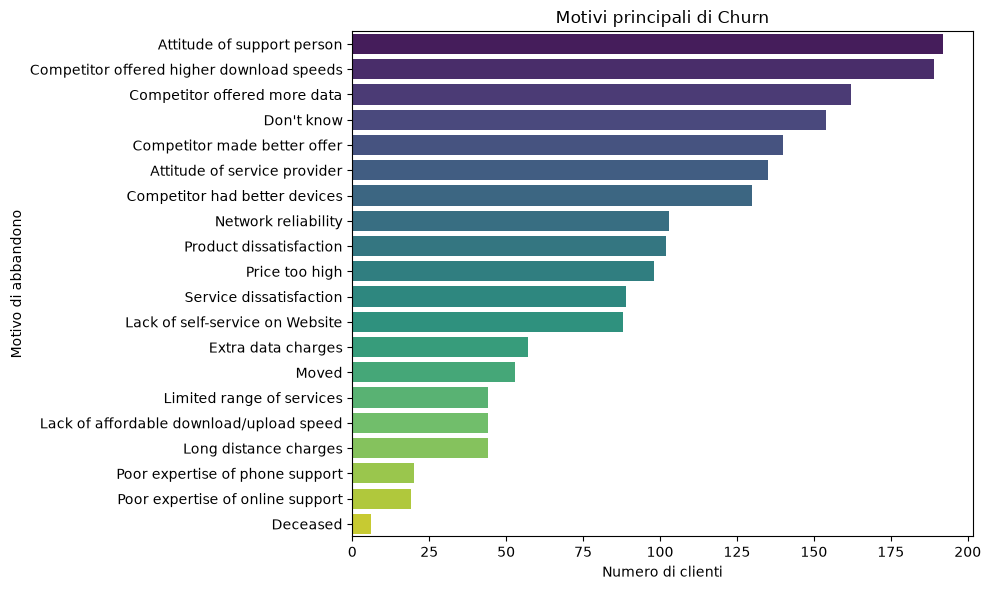

```python
churn_reasons = merged_df[merged_df['Churn'] == 'Yes']['Churn Reason']
reason_counts = churn_reasons.value_counts()

reason_df = reason_counts.reset_index()
reason_df.columns = ['Reason', 'Count']

plt.figure(figsize=(10, 6))
sns.barplot(data=reason_df, x='Count', y='Reason', hue='Reason', dodge=False, palette='viridis')

plt.title('Motivi principali di Churn')
plt.xlabel('Numero di clienti')
plt.ylabel('Motivo di abbandono')
plt.legend([], [], frameon=False)
plt.tight_layout()
plt.show()
```

```python
merged_df = merged_df.drop(columns=['Churn Reason'])
```

Ci sono ancora alcuni attributi da esaminare più attentamente. È il caso di Tech Support e Premium Tech Support

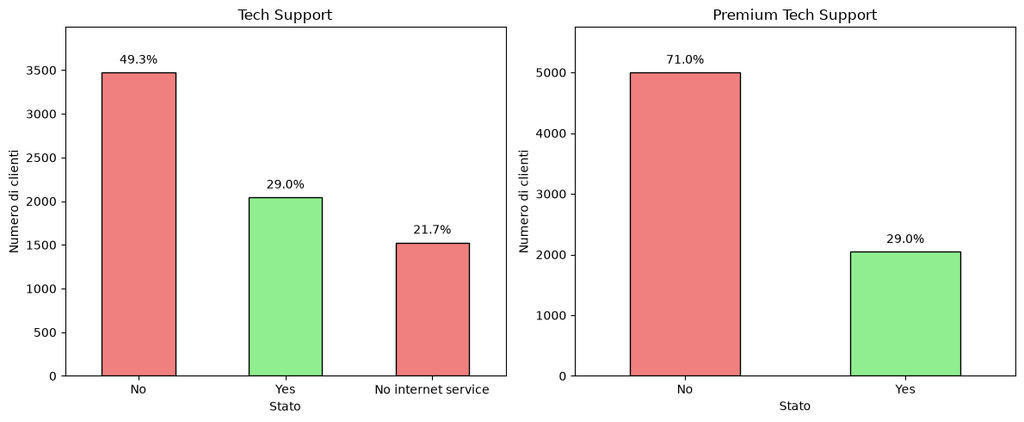

```python
ts_counts  = merged_df['Tech Support'].value_counts()
pts_counts = merged_df['Premium Tech Support'].value_counts()

fig, axes = plt.subplots(1, 2, figsize=(12, 5))

bars_ts = ts_counts.plot(
    kind='bar',
    color=['lightcoral', 'lightgreen'], edgecolor='black',
    ax=axes[0]
)
axes[0].set_title('Tech Support')
axes[0].set_ylabel('Numero di clienti')
axes[0].set_xlabel('Stato')
axes[0].tick_params(rotation=0)

max_ts = ts_counts.max()
axes[0].set_ylim(0, max_ts * 1.15)

total_ts = ts_counts.sum()
for i, value in enumerate(ts_counts):
    percent = f'{(value / total_ts * 100):.1f}%'
    axes[0].text(i, value + max_ts * 0.02, percent, ha='center', va='bottom')

bars_pts = pts_counts.plot(
    kind='bar',
    color=['lightcoral', 'lightgreen'], edgecolor='black',
    ax=axes[1]
)
axes[1].set_title('Premium Tech Support')
axes[1].set_ylabel('Numero di clienti')
axes[1].set_xlabel('Stato')
axes[1].tick_params(rotation=0)

max_pts = pts_counts.max()
axes[1].set_ylim(0, max_pts * 1.15)

total_pts = pts_counts.sum()
for i, value in enumerate(pts_counts):
    percent = f'{(value / total_pts * 100):.1f}%'
    axes[1].text(i, value + max_pts * 0.02, percent, ha='center', va='bottom')

plt.tight_layout()
plt.show()
```

La feature Premium Tech Support risulta più significativa per lo studio, pertanto elimineremo l'attributo Tech Support.

```python
merged_df = merged_df.drop(columns=['Tech Support'])
```

L'analisi prosegue con Device Protection e Device Protection Plan

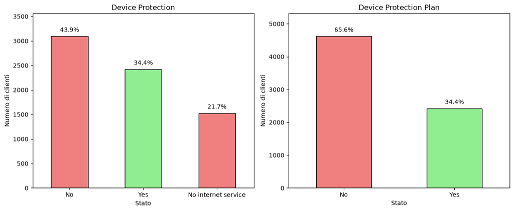

```python
dp_counts  = merged_df['Device Protection'].value_counts()
dpp_counts = merged_df['Device Protection Plan'].value_counts()

fig, axes = plt.subplots(1, 2, figsize=(12, 5))

dp_counts.plot(
    kind='bar',
    color=['lightcoral', 'lightgreen'], edgecolor='black',
    ax=axes[0]
)
axes[0].set_title('Device Protection')
axes[0].set_ylabel('Numero di clienti')
axes[0].set_xlabel('Stato')
axes[0].tick_params(rotation=0)

max_dp = dp_counts.max()
total_dp = dp_counts.sum()
axes[0].set_ylim(0, max_dp * 1.15)
for i, value in enumerate(dp_counts):
    percent = f'{(value / total_dp * 100):.1f}%'
    axes[0].text(i, value + max_dp * 0.02, percent, ha='center', va='bottom')

dpp_counts.plot(
    kind='bar',
    color=['lightcoral', 'lightgreen'], edgecolor='black',
    ax=axes[1]
)
axes[1].set_title('Device Protection Plan')
axes[1].set_ylabel('Numero di clienti')
axes[1].set_xlabel('Stato')
axes[1].tick_params(rotation=0)

max_dpp = dpp_counts.max()
total_dpp = dpp_counts.sum()
axes[1].set_ylim(0, max_dpp * 1.15)
for i, value in enumerate(dpp_counts):
    percent = f'{(value / total_dpp * 100):.1f}%'
    axes[1].text(i, value + max_dpp * 0.02, percent, ha='center', va='bottom')

plt.tight_layout()
plt.show()
```

In questo caso, la feature Device Protection Plan risulta più significativa per lo studio, pertanto elimineremo l'attributo Device Protection.

```python
merged_df = merged_df.drop(columns=['Device Protection'])
```

A questo punto, cerchiamo di comprendere quali dati per verificare quali saranno utili alla classificazione e quali no

## **Analisi degli attributi demografici**

```python
unique_countries = merged_df['Country'].unique()
print("Paesi presenti nel dataset:", unique_countries)
```

```
Paesi presenti nel dataset: <StringArray>
['United States']
Length: 1, dtype: str
```

Ad esempio, la colonna Country non è utile poichè il dataset include solo gli Stati Uniti. Controlliamo gli Stati:

```python
unique_countries = merged_df['State'].unique()
print("Paesi presenti nel dataset:", unique_countries)
```

```
Paesi presenti nel dataset: <StringArray>
['California']
Length: 1, dtype: str
```

Anche questa risulta una colonna superflua. Contrlliamo ora City:

```python
unique_cities = merged_df['City'].unique()
print("Città presenti nel dataset:", unique_cities)
unique_cities.size
```

```
Città presenti nel dataset: <StringArray>
[     'Frazier Park',          'Glendale',        'Costa Mesa',
          'Martinez',         'Camarillo',          'Midpines',
            'Lompoc',              'Napa',       'Simi Valley',
          'Sheridan',
 ...
             'Vidal',         'Earlimart',           'Mineral',
      'Tranquillity',          'Paskenta', 'Green Valley Lake',
       'Watsonville',            'Burson',       'Carpinteria',
     'Meadow Valley']
Length: 1129, dtype: str
```

```
1129
```

Controlliamo la distribuzione dei clienti nelle diverse citta.

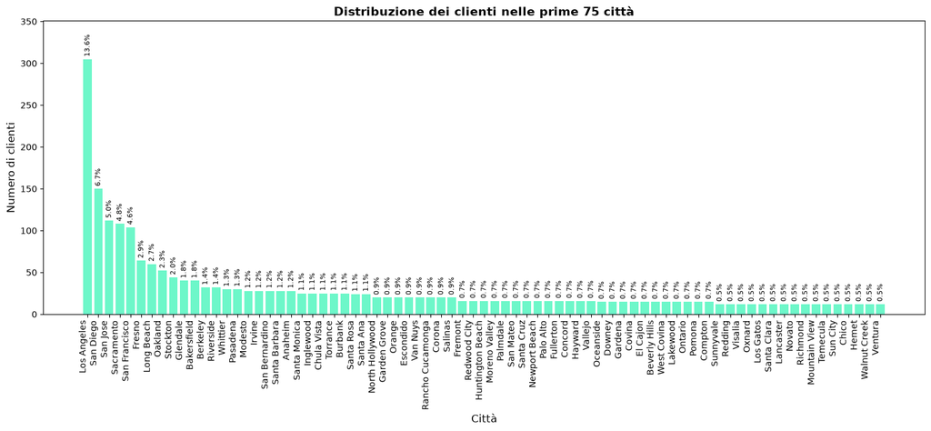

```python
n_cities = 75
city_counts = merged_df['City'].value_counts()
top_cities = city_counts.head(n_cities)
total = top_cities.sum()
max_val = top_cities.max()

plt.figure(figsize=(15, 7))
bars = plt.bar(top_cities.index, top_cities.values, color='#6df7c9')

for bar in bars:
    height = bar.get_height()
    plt.text(bar.get_x() + bar.get_width()/2, height + max_val * 0.01,
             f'{(height/total)*100:.1f}%', ha='center', va='bottom', fontsize=8, rotation=90)

plt.ylim(0, max_val * 1.15)
plt.title(f'Distribuzione dei clienti nelle prime {n_cities} città', fontsize=14, fontweight='bold')
plt.xlabel('Città', fontsize=12)
plt.ylabel('Numero di clienti', fontsize=12)
plt.xticks(rotation=90, ha='right')
plt.tight_layout()
plt.show()
```

```python
merged_df = merged_df.drop(['Country', 'State', 'City', 'Lat Long', 'Zip Code'], axis=1)
```

A questo punto, il dataset risulta essere

```python
merged_df.head()
print(merged_df.info())
```

```
<class 'pandas.DataFrame'>
RangeIndex: 7043 entries, 0 to 7042
Data columns (total 32 columns):
 #   Column                             Non-Null Count  Dtype
---  ------                             --------------  -----
 0   Customer ID                        7043 non-null   str
 1   Partner                            7043 non-null   str
 2   Tenure                             7043 non-null   int64
 3   Phone Service                      7043 non-null   str
 4   Multiple Lines                     7043 non-null   str
 5   Internet Service                   7043 non-null   str
 6   Online Security                    7043 non-null   str
 7   Online Backup                      7043 non-null   str
 8   Streaming TV                       7043 non-null   str
 9   Streaming Movies                   7043 non-null   str
```

[output cut: 25 more lines]

A questo punto, possiamo analizzare i dati contenuti nel datast più nello specifico. Iniziamo dal controllare la distribuzione dei clienti che fanno Churn.

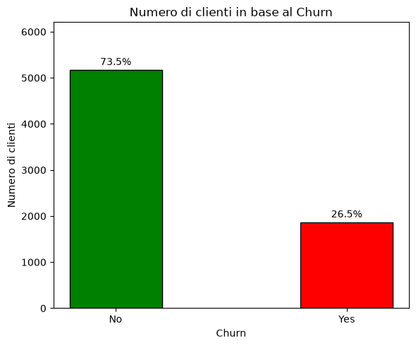

```python
count_per_churn = merged_df['Churn'].value_counts()
total_left = count_per_churn.sum()
max_val_left = count_per_churn.max()

palette = {'Yes': 'red', 'No': 'green'}
colors = [palette.get(val, 'gray') for val in count_per_churn.index]

fig, ax = plt.subplots(figsize=(6, 5))

bars = ax.bar(count_per_churn.index, count_per_churn.values, width=0.4, color=colors, edgecolor='black')
ax.set_title('Numero di clienti in base al Churn')
ax.set_xlabel('Churn')
ax.set_ylabel('Numero di clienti')
ax.set_ylim(0, max_val_left * 1.2)

for i, v in enumerate(count_per_churn.values):
    ax.text(i, v + max_val_left * 0.01, f'{(v/total_left)*100:.1f}%', ha='center', va='bottom')

plt.tight_layout()
plt.show()
```

Seguita dalla distribuzione dei generi e delle età.

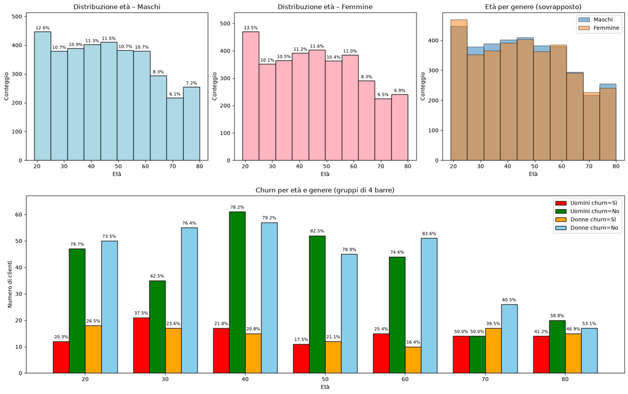

```python
counts_age = (
    merged_df
    .groupby(['Age','Gender','Churn'], observed=True)
    .size()
    .unstack(['Gender','Churn'])
    .fillna(0)
)

male_ages   = merged_df.loc[merged_df['Gender']=='Male',   'Age']
female_ages = merged_df.loc[merged_df['Gender']=='Female', 'Age']

age_ticks = list(range(20, 81, 10))
x         = np.arange(len(age_ticks))
bar_w     = 0.2

male_yes   = counts_age.loc[age_ticks, ('Male',   'Yes')].fillna(0)
male_no    = counts_age.loc[age_ticks, ('Male',   'No')].fillna(0)
female_yes = counts_age.loc[age_ticks, ('Female', 'Yes')].fillna(0)
female_no  = counts_age.loc[age_ticks, ('Female', 'No')].fillna(0)

fig = plt.figure(figsize=(16, 10), constrained_layout=True)
gs  = GridSpec(2, 3, figure=fig, height_ratios=[1, 1.2], hspace=0.05)

ax0 = fig.add_subplot(gs[0, 0])
n_m, bins_m, patches_m = ax0.hist(male_ages, bins=10, color='lightblue', edgecolor='black')
total_m = n_m.sum()
max_m   = n_m.max()
ax0.set_title('Distribuzione età – Maschi')
ax0.set_xlabel('Età')
ax0.set_ylabel('Conteggio')
ax0.set_ylim(0, max_m * 1.15)
for count, patch in zip(n_m, patches_m):
    if count > 0:
        x_c = patch.get_x() + patch.get_width()/2
        ax0.text(x_c, count + max_m*0.01, f'{(count/total_m)*100:.1f}%',
                 ha='center', va='bottom', fontsize=8)

ax1 = fig.add_subplot(gs[0, 1])
n_f, bins_f, patches_f = ax1.hist(female_ages, bins=10, color='lightpink', edgecolor='black')
total_f = n_f.sum()
max_f   = n_f.max()
ax1.set_title('Distribuzione età – Femmine')
ax1.set_xlabel('Età')
ax1.set_ylabel('Conteggio')
ax1.set_ylim(0, max_f * 1.15)
for count, patch in zip(n_f, patches_f):
    if count > 0:
        x_c = patch.get_x() + patch.get_width()/2
        ax1.text(x_c, count + max_f*0.01, f'{(count/total_f)*100:.1f}%',
                 ha='center', va='bottom', fontsize=8)

ax2 = fig.add_subplot(gs[0, 2])
ax2.hist(male_ages,   bins=10, alpha=0.5, label='Maschi',  edgecolor='black')
ax2.hist(female_ages, bins=10, alpha=0.5, label='Femmine', edgecolor='black')
ax2.set_title('Età per genere (sovrapposto)')
ax2.set_xlabel('Età')
ax2.set_ylabel('Conteggio')
ax2.legend()

ax3 = fig.add_subplot(gs[1, :])
totals = male_yes + male_no + female_yes + female_no
max_tot = totals.max()
ax3.set_title('Churn per età e genere (gruppi di 4 barre)')
ax3.set_xlabel('Età')
ax3.set_ylabel('Numero di clienti')
ax3.margins(y=0.10)

ax3.bar(x - 1.5*bar_w, male_yes,   width=bar_w, color='red',     label='Uomini churn=Sì', edgecolor='black')
ax3.bar(x - 0.5*bar_w, male_no,    width=bar_w, color='green',   label='Uomini churn=No',  edgecolor='black')
ax3.bar(x + 0.5*bar_w, female_yes, width=bar_w, color='orange',  label='Donne churn=Sì',   edgecolor='black')
ax3.bar(x + 1.5*bar_w, female_no,  width=bar_w, color='skyblue', label='Donne churn=No',   edgecolor='black')

male_tot   = male_yes + male_no
female_tot = female_yes + female_no

y_max = pd.concat([male_tot, female_tot]).max()

for idx, container in enumerate(ax3.containers):
    for i, bar in enumerate(container):
        height = bar.get_height()
        if height == 0:
            continue
        if idx < 2:
            denom = male_tot.iloc[i]
        else:
            denom = female_tot.iloc[i]
        pct = (height / denom) * 100 if denom > 0 else 0.0
        ax3.text(
            bar.get_x() + bar.get_width()/2,
            height + y_max*0.01,
            f'{pct:.1f}%',
            ha='center',
            va='bottom',
            fontsize=8
        )

ax3.set_xticks(x)
ax3.set_xticklabels(age_ticks, rotation=0, ha='center', fontsize=10)
ax3.legend(loc='upper right')

plt.show()
```

Come possiamo osservare, il genere non risulta causa di eccessive differenze di Churn. Tuttavia, al variare dell'età, il churn viene influenzato. Controlliamo ora se l'essere impegnato in una relazione possa influire sul Churn.

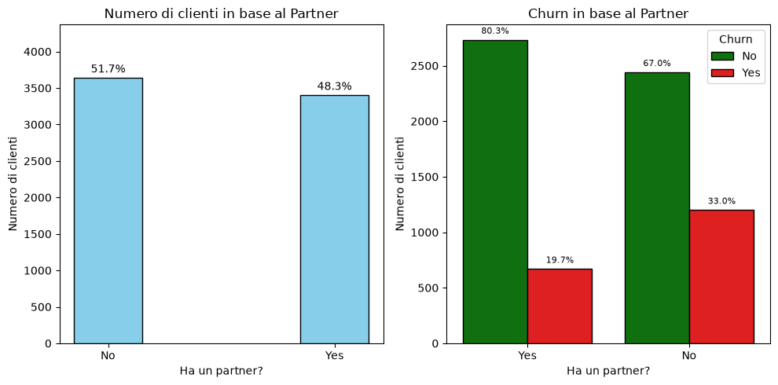

```python
count_per_type = merged_df['Partner'].value_counts()
total_left = count_per_type.sum()
max_val_left = count_per_type.max()

churn_counts = merged_df.groupby(['Partner', 'Churn']).size().unstack().fillna(0)
max_val_right = churn_counts.values.sum(axis=1).max()

palette = {'Yes': 'red', 'No': 'green'}

fig, axes = plt.subplots(1, 2, figsize=(10, 5))

bars = axes[0].bar(count_per_type.index, count_per_type.values, width=0.3, color='skyblue', edgecolor='black')
axes[0].set_title('Numero di clienti in base al Partner')
axes[0].set_xlabel('Ha un partner?')
axes[0].set_ylabel('Numero di clienti')
axes[0].tick_params(rotation=0)
axes[0].set_ylim(0, max_val_left * 1.2)

for i, v in enumerate(count_per_type.values):
    axes[0].text(i, v + max_val_left * 0.01, f'{(v/total_left)*100:.1f}%', ha='center', va='bottom')

sns.countplot(
    data=merged_df,
    x='Partner',
    hue='Churn',
    palette=palette,
    edgecolor='black',
    ax=axes[1]
)

total_right = merged_df.groupby('Partner').size()

for j, container in enumerate(axes[1].containers):
    for i, bar in enumerate(container):
        height = bar.get_height()
        if height == 0:
            continue
        service = bar.get_x() + bar.get_width() / 2
        partner = bar.get_label()
        partner_value = merged_df['Partner'].unique()[i % len(total_right)]
        relative_total = total_right[partner_value]
        pct = (height / relative_total) * 100
        axes[1].text(
            bar.get_x() + bar.get_width()/2,
            bar.get_height() + max_val_right*0.01,
            f'{pct:.1f}%',
            ha='center', va='bottom', fontsize=8
        )

axes[1].set_title('Churn in base al Partner')
axes[1].set_xlabel('Ha un partner?')
axes[1].set_ylabel('Numero di clienti')
axes[1].legend(title='Churn', loc='upper right')

plt.tight_layout()
plt.show()
```

L'avere un partner riduce la quantità di clienti che fa Churn. Dunque, questo attributo verrò coinvolto nella classificazione.

Verifichiamo inoltre, se il numero di famigliari a carico possa influenzare il target.

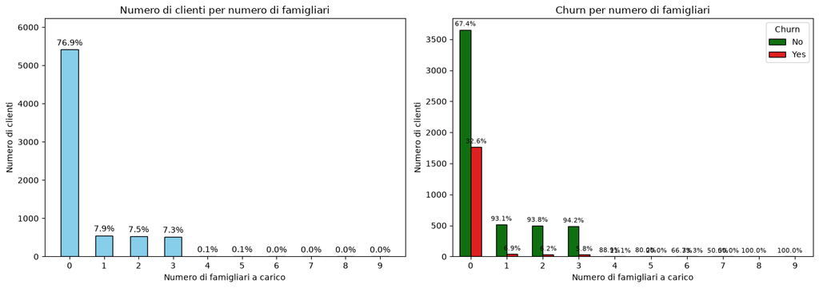

```python
dependents_order = sorted(merged_df['Number of Dependents'].unique())

count_per_type = merged_df['Number of Dependents'].value_counts().reindex(dependents_order, fill_value=0)
total_left     = count_per_type.sum()
max_val_left   = count_per_type.max()

churn_counts   = merged_df.groupby(['Number of Dependents', 'Churn']).size().unstack().fillna(0)
total_right    = churn_counts.sum(axis=1).reindex(dependents_order, fill_value=0)
max_val_right  = churn_counts.values.max()

palette = {'Yes': 'red', 'No': 'green'}

fig, axes = plt.subplots(1, 2, figsize=(14, 5))

bars = axes[0].bar(count_per_type.index.astype(str), count_per_type.values,
                   width=0.5, color='skyblue', edgecolor='black')
axes[0].set_title('Numero di clienti per numero di famigliari')
axes[0].set_xlabel('Numero di famigliari a carico')
axes[0].set_ylabel('Numero di clienti')
axes[0].set_ylim(0, max_val_left * 1.15)

for i, v in enumerate(count_per_type.values):
    axes[0].text(i, v + max_val_left * 0.01,
                 f'{(v/total_left)*100:.1f}%',
                 ha='center', va='bottom')

ax = axes[1]
sns.countplot(
    data=merged_df,
    x='Number of Dependents',
    hue='Churn',
    palette=palette,
    edgecolor='black',
    width=0.6,
    ax=ax,
    order=dependents_order,
    hue_order=['No', 'Yes']
)

for j, container in enumerate(ax.containers):
    churn_cat = ['No', 'Yes'][j]
    for i, bar in enumerate(container):
        height = bar.get_height()
        if height == 0:
            continue

        dependents = dependents_order[i]
        total = total_right[dependents]
        pct = (height / total) * 100

        ax.text(
            bar.get_x() + bar.get_width()/2,
            height + max_val_right * 0.01,
            f'{pct:.1f}%',
            ha='center', va='bottom', fontsize=8
        )

ax.set_title('Churn per numero di famigliari')
ax.set_xlabel('Numero di famigliari a carico')
ax.set_ylabel('Numero di clienti')
ax.legend(title='Churn', loc='upper right')

plt.tight_layout()
plt.show()
```

Questo attributo risulta essere informativo: all'aumentare dei famigliari a carico il churn tende a diminuire significativamente.

## **Analisi degli attributi relativi ai servizi attivi**

Controlliamo ora tutti i servizi sottoscritti, verificando innanzitutto, la distribuzione dei clienti in relazione alla loro connessione Internet.

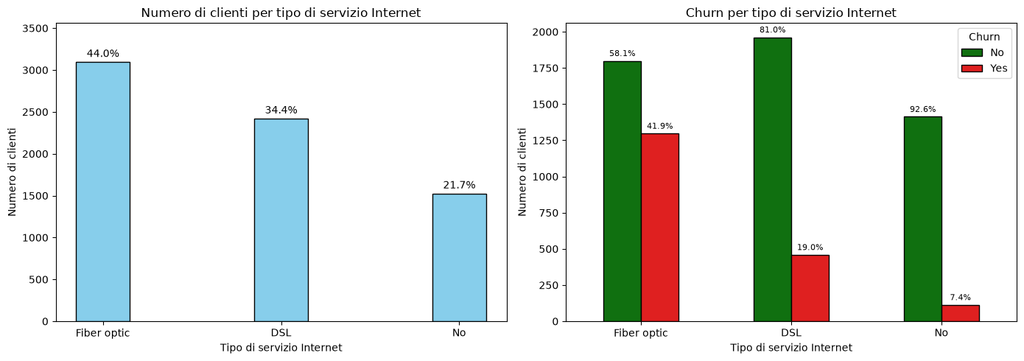

```python
count_per_type = merged_df['Internet Service'].value_counts()
total_left     = count_per_type.sum()
max_val_left   = count_per_type.max()

churn_counts   = merged_df.groupby(['Internet Service', 'Churn']).size().unstack().fillna(0)
total_right    = churn_counts.sum(axis=1)
max_val_right  = churn_counts.values.max()  # non sum(axis=1).sum(), ma il massimo delle barre

palette = {'Yes': 'red', 'No': 'green'}

fig, axes = plt.subplots(1, 2, figsize=(14, 5))

# — Grafico a sinistra unchanged — #
bars = axes[0].bar(count_per_type.index, count_per_type.values,
                   width=0.3, color='skyblue', edgecolor='black')
axes[0].set_title('Numero di clienti per tipo di servizio Internet')
axes[0].set_xlabel('Tipo di servizio Internet')
axes[0].set_ylabel('Numero di clienti')
axes[0].set_ylim(0, max_val_left * 1.15)

for i, v in enumerate(count_per_type.values):
    axes[0].text(i, v + max_val_left * 0.01,
                 f'{(v/total_left)*100:.1f}%',
                 ha='center', va='bottom')

# — Grafico a destra con countplot — #
ax = axes[1]
sns.countplot(
    data=merged_df,
    x='Internet Service',
    hue='Churn',
    palette=palette,
    edgecolor='black',
    width=0.5,
    ax=ax,
    order=count_per_type.index,  # per sicurezza
    hue_order=['No','Yes']
)

# Sostituisci il vecchio loop su patches con questo:
# ax.containers[0] = barre Churn='No'; ax.containers[1] = barre Churn='Yes'
for j, container in enumerate(ax.containers):
    churn_cat = ['No', 'Yes'][j]
    for i, bar in enumerate(container):
        height  = bar.get_height()
        if height == 0:
            continue

        service = count_per_type.index[i]
        total   = total_right[service]
        pct     = (height / total) * 100

        ax.text(
            bar.get_x() + bar.get_width()/2,
            height + max_val_right * 0.01,
            f'{pct:.1f}%',
            ha='center', va='bottom', fontsize=8
        )

ax.set_title('Churn per tipo di servizio Internet')
ax.set_xlabel('Tipo di servizio Internet')
ax.set_ylabel('Numero di clienti')
ax.legend(title='Churn', loc='upper right')

plt.tight_layout()
plt.show()
```

Osserviamo che la maggior parte dei clienti che fa Churn sono gli stessi che sottoscrivono un contratto di fibra ottica. Questo valore risulta essere determinante nella determinazione del Churn. Analizziamo ora il servizio Online Backup.

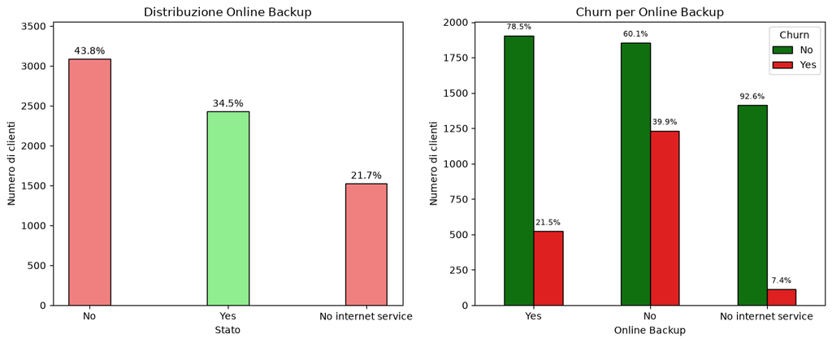

```python
count_per_type = merged_df['Online Backup'].value_counts()
total_left = count_per_type.sum()
max_val_left = count_per_type.max()

churn_counts = merged_df.groupby(['Online Backup', 'Churn']).size().unstack().fillna(0)
total_right = churn_counts.sum(axis=1)
max_val_right = churn_counts.values.sum(axis=1).max()

palette = {'Yes': 'red', 'No': 'green'}

fig, axes = plt.subplots(1, 2, figsize=(12, 5))

axes[0].bar(count_per_type.index, count_per_type.values, width=0.3, color=['lightcoral', 'lightgreen'], edgecolor='black')
axes[0].set_title('Distribuzione Online Backup')
axes[0].set_xlabel('Stato')
axes[0].set_ylabel('Numero di clienti')
axes[0].tick_params(rotation=0)
axes[0].set_ylim(0, max_val_left * 1.15)

for i, v in enumerate(count_per_type.values):
    axes[0].text(i, v + max_val_left * 0.01, f'{(v/total_left)*100:.1f}%', ha='center', va='bottom')

sns.countplot(
    data=merged_df,
    x='Online Backup',
    hue='Churn',
    palette=palette,
    edgecolor='black',
    width=0.5,
    ax=axes[1]
)

x_labels = [t.get_text() for t in axes[1].get_xticklabels()]

total_right   = churn_counts.sum(axis=1)
max_val_right = total_right.max()

for j, container in enumerate(axes[1].containers):
    for i, bar in enumerate(container):
        height = bar.get_height()
        if height == 0:
            continue

        service       = x_labels[i]
        relativeTotal = total_right[service]

        pct = height / relativeTotal * 100

        x = bar.get_x() + bar.get_width() / 2
        y = height + max_val_right * 0.01

        axes[1].text(
            x, y,
            f'{pct:.1f}%',
            ha='center', va='bottom',
            fontsize=8
        )

axes[1].set_title('Churn per Online Backup')
axes[1].set_xlabel('Online Backup')
axes[1].set_ylabel('Numero di clienti')
axes[1].legend(title='Churn', loc='upper right')
plt.tight_layout()
plt.show()
```

Questo risulta essere un attributo estremamente significativo per l'abbandono: i clienti che sottoscrivono un servizio di backup tendono ad abbandonare meno spesso la compagnia di telecomunicazioni. Proseguiamo con l'analisi dell'attributo Online Security.

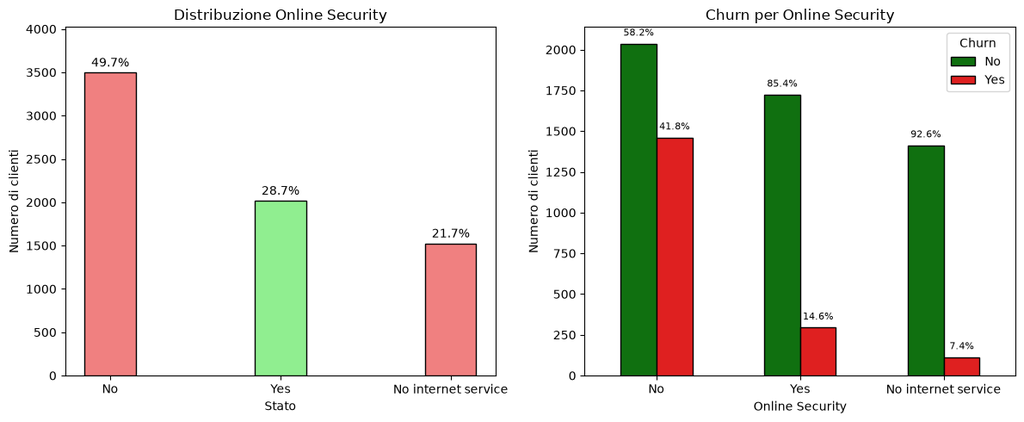

```python
count_per_type = merged_df['Online Security'].value_counts()
total_left = count_per_type.sum()
max_val_left = count_per_type.max()

churn_counts = merged_df.groupby(['Online Security', 'Churn']).size().unstack().fillna(0)
total_right = churn_counts.sum(axis=1)
max_val_right = churn_counts.values.sum(axis=1).max()

palette = {'Yes': 'red', 'No': 'green'}

fig, axes = plt.subplots(1, 2, figsize=(12, 5))

axes[0].bar(count_per_type.index, count_per_type.values, width=0.3, color=['lightcoral', 'lightgreen'], edgecolor='black')
axes[0].set_title('Distribuzione Online Security')
axes[0].set_xlabel('Stato')
axes[0].set_ylabel('Numero di clienti')
axes[0].tick_params(rotation=0)
axes[0].set_ylim(0, max_val_left * 1.15)

for i, v in enumerate(count_per_type.values):
    axes[0].text(i, v + max_val_left * 0.01, f'{(v/total_left)*100:.1f}%', ha='center', va='bottom')

sns.countplot(
    data=merged_df,
    x='Online Security',
    hue='Churn',
    palette=palette,
    edgecolor='black',
    width=0.5,
    ax=axes[1]
)

x_labels = [tick.get_text() for tick in axes[1].get_xticklabels()]

for j, container in enumerate(axes[1].containers):
    for i, bar in enumerate(container):
        height = bar.get_height()
        if height == 0:
            continue

        service = x_labels[i]
        relativeTotal = total_right[service]
        pct = (height / relativeTotal) * 100

        axes[1].text(
            bar.get_x() + bar.get_width() / 2,
            height + max_val_right * 0.01,
            f'{pct:.1f}%',
            ha='center',
            va='bottom',
            fontsize=8
        )

axes[1].set_title('Churn per Online Security')
axes[1].set_xlabel('Online Security')
axes[1].set_ylabel('Numero di clienti')
axes[1].legend(title='Churn', loc='upper right')

plt.tight_layout()
plt.show()
```

Anche questo attributo risulta essere molto significativo: i clienti che sottoscrivono il servizio di Online Security tendono ad abbandonare meno la compagnia di telecomunicazioni. Vediamo ora Device Protection Plan.

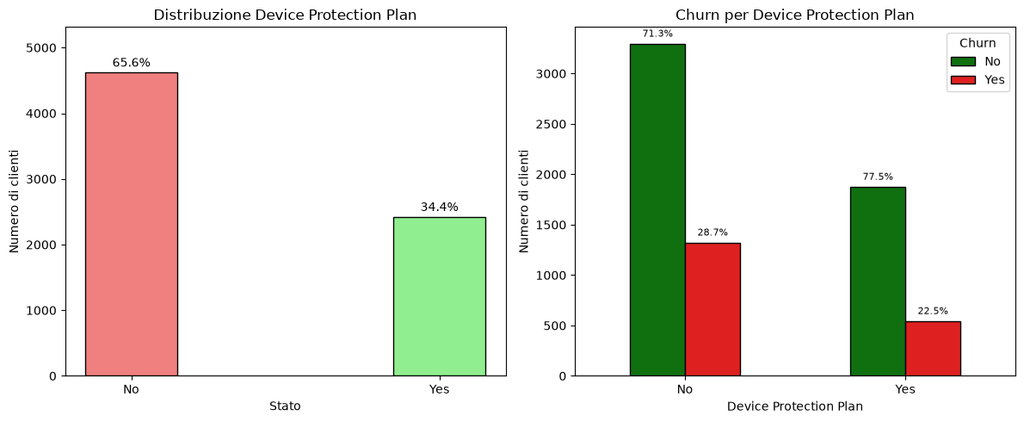

```python
count_per_type = merged_df['Device Protection Plan'].value_counts()
total_left = count_per_type.sum()
max_val_left = count_per_type.max()

churn_counts = merged_df.groupby(['Device Protection Plan', 'Churn']).size().unstack().fillna(0)
total_right = churn_counts.sum(axis=1)
max_val_right = churn_counts.values.sum(axis=1).max()

palette = {'Yes': 'red', 'No': 'green'}

fig, axes = plt.subplots(1, 2, figsize=(12, 5))

axes[0].bar(count_per_type.index, count_per_type.values, width=0.3, color=['lightcoral', 'lightgreen'], edgecolor='black')
axes[0].set_title('Distribuzione Device Protection Plan')
axes[0].set_xlabel('Stato')
axes[0].set_ylabel('Numero di clienti')
axes[0].tick_params(rotation=0)
axes[0].set_ylim(0, max_val_left * 1.15)

for i, v in enumerate(count_per_type.values):
    axes[0].text(i, v + max_val_left * 0.01, f'{(v/total_left)*100:.1f}%', ha='center', va='bottom')

sns.countplot(
    data=merged_df,
    x='Device Protection Plan',
    hue='Churn',
    palette=palette,
    edgecolor='black',
    width=0.5,
    ax=axes[1]
)

x_labels = [tick.get_text() for tick in axes[1].get_xticklabels()]

for j, container in enumerate(axes[1].containers):
    for i, bar in enumerate(container):
        height = bar.get_height()
        if height == 0:
            continue

        service = x_labels[i]
        relativeTotal = total_right[service]
        pct = (height / relativeTotal) * 100

        axes[1].text(
            bar.get_x() + bar.get_width() / 2,
            height + max_val_right * 0.01,
            f'{pct:.1f}%',
            ha='center',
            va='bottom',
            fontsize=8
        )

axes[1].set_title('Churn per Device Protection Plan')
axes[1].set_xlabel('Device Protection Plan')
axes[1].set_ylabel('Numero di clienti')
axes[1].legend(title='Churn', loc='upper right')

plt.tight_layout()
plt.show()
```

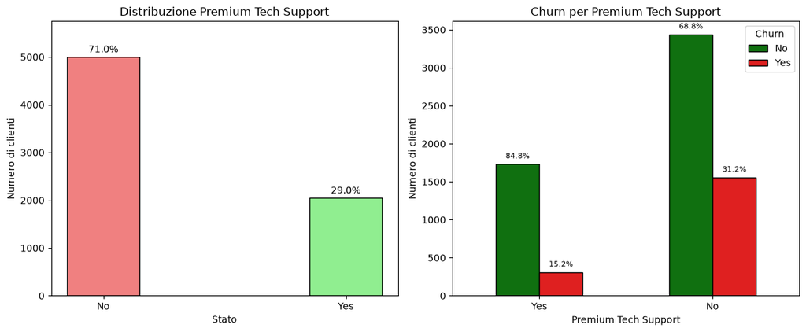

```python
count_per_type = merged_df['Premium Tech Support'].value_counts()
total_left = count_per_type.sum()
max_val_left = count_per_type.max()

churn_counts = merged_df.groupby(['Premium Tech Support', 'Churn']).size().unstack().fillna(0)
total_right = churn_counts.sum(axis=1)
max_val_right = churn_counts.values.sum(axis=1).max()

palette = {'Yes': 'red', 'No': 'green'}

fig, axes = plt.subplots(1, 2, figsize=(12, 5))

# Grafico distribuzione generale
axes[0].bar(count_per_type.index, count_per_type.values, width=0.3, color=['lightcoral', 'lightgreen'], edgecolor='black')
axes[0].set_title('Distribuzione Premium Tech Support')
axes[0].set_xlabel('Stato')
axes[0].set_ylabel('Numero di clienti')
axes[0].tick_params(rotation=0)
axes[0].set_ylim(0, max_val_left * 1.15)

for i, v in enumerate(count_per_type.values):
    axes[0].text(i, v + max_val_left * 0.01, f'{(v/total_left)*100:.1f}%', ha='center', va='bottom')

# Grafico churn per categoria
sns.countplot(
    data=merged_df,
    x='Premium Tech Support',
    hue='Churn',
    palette=palette,
    edgecolor='black',
    width=0.5,
    ax=axes[1]
)

x_labels = [t.get_text() for t in axes[1].get_xticklabels()]

total_right = churn_counts.sum(axis=1)
max_val_right = total_right.max()

for j, container in enumerate(axes[1].containers):
    for i, bar in enumerate(container):
        height = bar.get_height()
        if height == 0:
            continue

        service = x_labels[i]
        relativeTotal = total_right[service]

        pct = height / relativeTotal * 100

        x = bar.get_x() + bar.get_width() / 2
        y = height + max_val_right * 0.01

        axes[1].text(
            x, y,
            f'{pct:.1f}%',
            ha='center', va='bottom',
            fontsize=8
        )

axes[1].set_title('Churn per Premium Tech Support')
axes[1].set_xlabel('Premium Tech Support')
axes[1].set_ylabel('Numero di clienti')
axes[1].legend(title='Churn', loc='upper right')

plt.tight_layout()
plt.show()
```

Questo grafico riporta i valori dell'attributo Premium Tech Support, che è un risultato particolarmente significativo: solo una piccola percentuale dei clienti che aveva sottoscritto il servizio ha in seguito abbadonato. Passiamo quindi all'analisi degli attributi relativi all'offerta mobile, partendo dall'attributo Phone Service

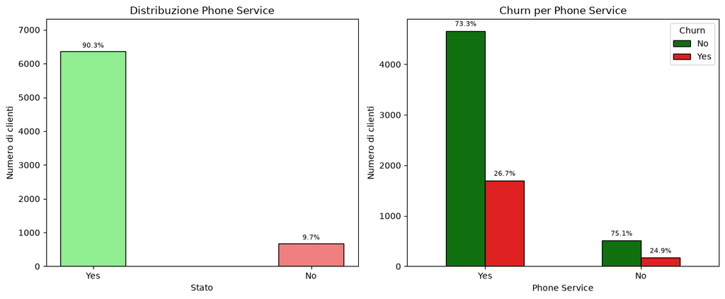

```python
palette = {'Yes': 'red', 'No': 'green'}

count_per_type = merged_df['Phone Service'].value_counts()
total_left = count_per_type.sum()
max_left = count_per_type.max()

fig, axes = plt.subplots(1, 2, figsize=(12, 5))

axes[0].bar(
    count_per_type.index,
    count_per_type.values,
    width=0.3,
    color=['lightgreen', 'lightcoral'],
    edgecolor='black'
)
axes[0].set_title('Distribuzione Phone Service')
axes[0].set_xlabel('Stato')
axes[0].set_ylabel('Numero di clienti')
axes[0].tick_params(axis='x', rotation=0)
axes[0].set_ylim(0, max_left * 1.15)

for i, v in enumerate(count_per_type.values):
    axes[0].text(
        i,
        v + max_left * 0.01,
        f'{(v/total_left)*100:.1f}%',
        ha='center',
        va='bottom',
        fontsize=8
    )

ax = axes[1]
sns.countplot(
    data=merged_df,
    x='Phone Service',
    hue='Churn',
    palette=palette,
    edgecolor='black',
    width=0.5,
    ax=ax
)
ax.set_title('Churn per Phone Service')
ax.set_xlabel('Phone Service')
ax.set_ylabel('Numero di clienti')
ax.legend(title='Churn', loc='upper right')

counts = merged_df['Phone Service'].value_counts()
categories = counts.index.tolist()
n_hue = merged_df['Churn'].nunique()
y_max = counts.max()

x_labels = [tick.get_text() for tick in ax.get_xticklabels()]
churn_totals = merged_df.groupby(['Phone Service', 'Churn']).size().unstack().fillna(0)
category_totals = churn_totals.sum(axis=1)
y_max = category_totals.max()

for j, container in enumerate(ax.containers):
    for i, bar in enumerate(container):
        height = bar.get_height()
        if height == 0:
            continue
        category = x_labels[i]
        total = category_totals[category]
        perc = (height / total) * 100

        ax.text(
            bar.get_x() + bar.get_width() / 2,
            height + y_max * 0.01,
            f'{perc:.1f}%',
            ha='center',
            va='bottom',
            fontsize=8
        )

plt.tight_layout()
plt.show()
```

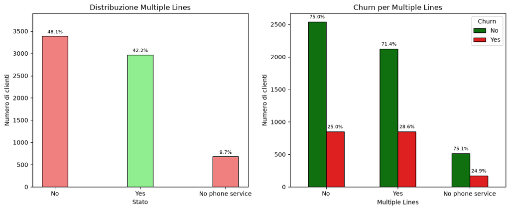

```python
count_per_type = merged_df['Multiple Lines'].value_counts()
total_left = count_per_type.sum()
max_left = count_per_type.max()

fig, axes = plt.subplots(1, 2, figsize=(12, 5))

axes[0].bar(
    count_per_type.index,
    count_per_type.values,
    width=0.3,
    color=['lightcoral', 'lightgreen'],
    edgecolor='black'
)
axes[0].set_title('Distribuzione Multiple Lines')
axes[0].set_xlabel('Stato')
axes[0].set_ylabel('Numero di clienti')
axes[0].tick_params(axis='x', rotation=0)
axes[0].set_ylim(0, max_left * 1.15)

for i, v in enumerate(count_per_type.values):
    axes[0].text(
        i,
        v + max_left * 0.01,
        f'{(v/total_left)*100:.1f}%',
        ha='center',
        va='bottom',
        fontsize=8
    )

ax = axes[1]
sns.countplot(
    data=merged_df,
    x='Multiple Lines',
    hue='Churn',
    palette=palette,
    edgecolor='black',
    width=0.5,
    ax=ax
)
ax.set_title('Churn per Multiple Lines')
ax.set_xlabel('Multiple Lines')
ax.set_ylabel('Numero di clienti')
ax.legend(title='Churn', loc='upper right')

counts = merged_df['Multiple Lines'].value_counts()
categories = counts.index.tolist()
n_hue = merged_df['Churn'].nunique()
y_max = counts.max()

x_labels = [tick.get_text() for tick in ax.get_xticklabels()]
churn_totals = merged_df.groupby(['Multiple Lines', 'Churn']).size().unstack().fillna(0)
category_totals = churn_totals.sum(axis=1)
y_max = category_totals.max()

for j, container in enumerate(ax.containers):
    for i, bar in enumerate(container):
        height = bar.get_height()
        if height == 0:
            continue
        category = x_labels[i]
        total = category_totals[category]
        perc = (height / total) * 100

        ax.text(
            bar.get_x() + bar.get_width() / 2,
            height + y_max * 0.01,
            f'{perc:.1f}%',
            ha='center',
            va='bottom',
            fontsize=8
        )

plt.tight_layout()
plt.show()
```

In ciascun caso, la percentuale di clienti è prossima al 25%, pertanto, riteniamo che questo valore non influisca sul Churn. Di conseguenza, non verrà usato nella classificazione. Controlliamo se l'attributo Unlimited Data può essere maggiormente rappresentativo.

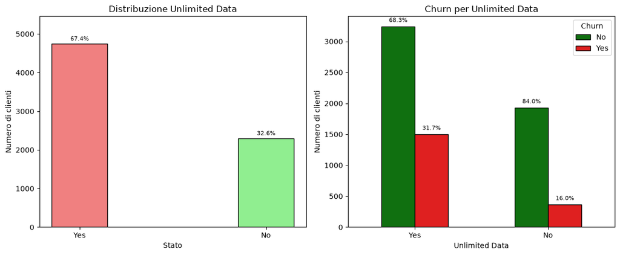

```python
count_per_type = merged_df['Unlimited Data'].value_counts()
total_left = count_per_type.sum()
max_left = count_per_type.max()

fig, axes = plt.subplots(1, 2, figsize=(12, 5))

axes[0].bar(
    count_per_type.index,
    count_per_type.values,
    width=0.3,
    color=['lightcoral', 'lightgreen'],
    edgecolor='black'
)
axes[0].set_title('Distribuzione Unlimited Data')
axes[0].set_xlabel('Stato')
axes[0].set_ylabel('Numero di clienti')
axes[0].tick_params(axis='x', rotation=0)
axes[0].set_ylim(0, max_left * 1.15)

for i, v in enumerate(count_per_type.values):
    axes[0].text(
        i,
        v + max_left * 0.01,
        f'{(v/total_left)*100:.1f}%',
        ha='center',
        va='bottom',
        fontsize=8
    )

ax = axes[1]
sns.countplot(
    data=merged_df,
    x='Unlimited Data',
    hue='Churn',
    palette=palette,
    edgecolor='black',
    width=0.5,
    ax=ax
)
ax.set_title('Churn per Unlimited Data')
ax.set_xlabel('Unlimited Data')
ax.set_ylabel('Numero di clienti')
ax.legend(title='Churn', loc='upper right')

counts = merged_df['Unlimited Data'].value_counts()
categories = counts.index.tolist()
n_hue = merged_df['Churn'].nunique()
y_max = counts.max()

x_labels = [tick.get_text() for tick in ax.get_xticklabels()]
churn_totals = merged_df.groupby(['Unlimited Data', 'Churn']).size().unstack().fillna(0)
category_totals = churn_totals.sum(axis=1)
y_max = category_totals.max()

for j, container in enumerate(ax.containers):
    for i, bar in enumerate(container):
        height = bar.get_height()
        if height == 0:
            continue
        category = x_labels[i]
        total = category_totals[category]
        perc = (height / total) * 100

        ax.text(
            bar.get_x() + bar.get_width() / 2,
            height + y_max * 0.01,
            f'{perc:.1f}%',
            ha='center',
            va='bottom',
            fontsize=8
        )

plt.tight_layout()
plt.show()
```

Viceversa, sembrerebbe che l'attributo in esame sia particolarmente significativo. Controlliamo dunuque, i servizi di streaming.

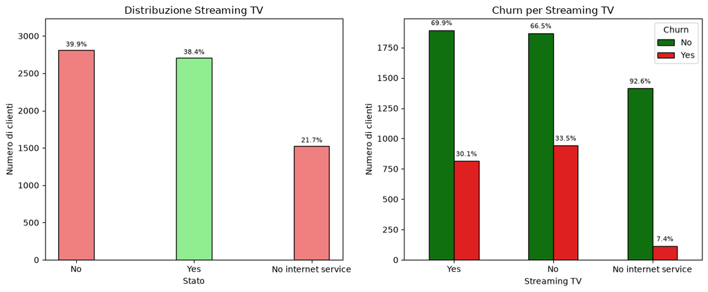

```python
count_per_type = merged_df['Streaming TV'].value_counts()
total_left = count_per_type.sum()
max_left = count_per_type.max()

fig, axes = plt.subplots(1, 2, figsize=(12, 5))

axes[0].bar(
    count_per_type.index,
    count_per_type.values,
    width=0.3,
    color=['lightcoral', 'lightgreen'],
    edgecolor='black'
)
axes[0].set_title('Distribuzione Streaming TV')
axes[0].set_xlabel('Stato')
axes[0].set_ylabel('Numero di clienti')
axes[0].tick_params(axis='x', rotation=0)
axes[0].set_ylim(0, max_left * 1.15)

for i, v in enumerate(count_per_type.values):
    axes[0].text(
        i,
        v + max_left * 0.01,
        f'{(v/total_left)*100:.1f}%',
        ha='center',
        va='bottom',
        fontsize=8
    )

ax = axes[1]
sns.countplot(
    data=merged_df,
    x='Streaming TV',
    hue='Churn',
    palette=palette,
    edgecolor='black',
    width=0.5,
    ax=ax
)
ax.set_title('Churn per Streaming TV')
ax.set_xlabel('Streaming TV')
ax.set_ylabel('Numero di clienti')
ax.legend(title='Churn', loc='upper right')

counts = merged_df['Streaming TV'].value_counts()
categories = counts.index.tolist()
n_hue = merged_df['Churn'].nunique()
y_max = counts.max()

x_labels = [tick.get_text() for tick in ax.get_xticklabels()]
churn_totals = merged_df.groupby(['Streaming TV', 'Churn']).size().unstack().fillna(0)
category_totals = churn_totals.sum(axis=1)
y_max = category_totals.max()

for j, container in enumerate(ax.containers):
    for i, bar in enumerate(container):
        height = bar.get_height()
        if height == 0:
            continue
        category = x_labels[i]
        total = category_totals[category]
        perc = (height / total) * 100

        ax.text(
            bar.get_x() + bar.get_width() / 2,
            height + y_max * 0.01,
            f'{perc:.1f}%',
            ha='center',
            va='bottom',
            fontsize=8
        )

plt.tight_layout()
plt.show()
```

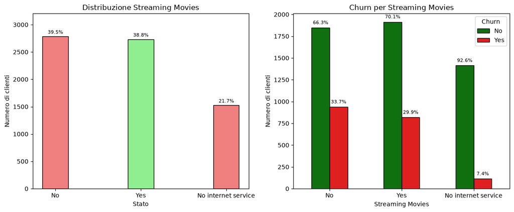

```python
count_per_type = merged_df['Streaming Movies'].value_counts()
total_left = count_per_type.sum()
max_left = count_per_type.max()

fig, axes = plt.subplots(1, 2, figsize=(12, 5))

axes[0].bar(
    count_per_type.index,
    count_per_type.values,
    width=0.3,
    color=['lightcoral', 'lightgreen'],
    edgecolor='black'
)
axes[0].set_title('Distribuzione Streaming Movies')
axes[0].set_xlabel('Stato')
axes[0].set_ylabel('Numero di clienti')
axes[0].tick_params(axis='x', rotation=0)
axes[0].set_ylim(0, max_left * 1.15)

for i, v in enumerate(count_per_type.values):
    axes[0].text(
        i,
        v + max_left * 0.01,
        f'{(v/total_left)*100:.1f}%',
        ha='center',
        va='bottom',
        fontsize=8
    )

ax = axes[1]
sns.countplot(
    data=merged_df,
    x='Streaming Movies',
    hue='Churn',
    palette=palette,
    edgecolor='black',
    width=0.5,
    ax=ax
)
ax.set_title('Churn per Streaming Movies')
ax.set_xlabel('Streaming Movies')
ax.set_ylabel('Numero di clienti')
ax.legend(title='Churn', loc='upper right')

counts = merged_df['Streaming Movies'].value_counts()
categories = counts.index.tolist()
n_hue = merged_df['Churn'].nunique()
y_max = counts.max()

x_labels = [tick.get_text() for tick in ax.get_xticklabels()]
churn_totals = merged_df.groupby(['Streaming Movies', 'Churn']).size().unstack().fillna(0)
category_totals = churn_totals.sum(axis=1)
y_max = category_totals.max()

for j, container in enumerate(ax.containers):
    for i, bar in enumerate(container):
        height = bar.get_height()
        if height == 0:
            continue
        category = x_labels[i]
        total = category_totals[category]
        perc = (height / total) * 100

        ax.text(
            bar.get_x() + bar.get_width() / 2,
            height + y_max * 0.01,
            f'{perc:.1f}%',
            ha='center',
            va='bottom',
            fontsize=8
        )

plt.tight_layout()
plt.show()
```

Anche in questo caso, la sottoscrizione del servizio comporta notevoli differenze di Churn nei clienti che non hanno un servizio internet. Analizziamo dunque, Streaming Music.

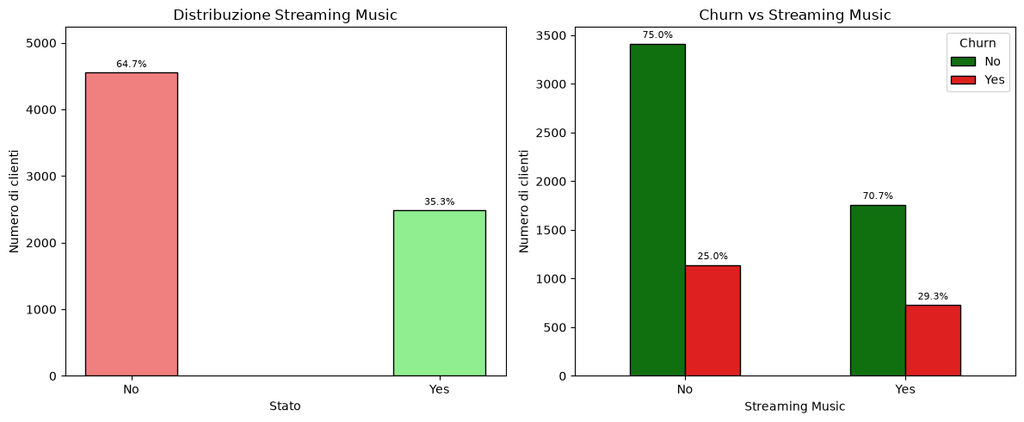

```python
palette = {'No': 'green', 'Yes': 'red'}

fig, axes = plt.subplots(1, 2, figsize=(12, 5))

count_per_type = merged_df['Streaming Music'].value_counts()
total_left = count_per_type.sum()
max_left = count_per_type.max()

axes[0].bar(
    count_per_type.index,
    count_per_type.values,
    width=0.3,
    color=['lightcoral', 'lightgreen'],
    edgecolor='black'
)
axes[0].set_title('Distribuzione Streaming Music')
axes[0].set_xlabel('Stato')
axes[0].set_ylabel('Numero di clienti')
axes[0].set_ylim(0, max_left * 1.15)

for i, v in enumerate(count_per_type.values):
    pct = (v / total_left) * 100
    axes[0].text(
        i,
        v + max_left * 0.01,
        f'{pct:.1f}%',
        ha='center', va='bottom', fontsize=8
    )

x_order  = ['No', 'Yes']
hue_order = ['No', 'Yes']

ax = axes[1]
sns.countplot(
    data=merged_df,
    x='Streaming Music',
    hue='Churn',
    palette=palette,
    edgecolor='black',
    width=0.5,
    ax=ax,
    order=x_order,
    hue_order=hue_order
)

grouped = (
    merged_df
    .groupby(['Streaming Music', 'Churn'])
    .size()
    .unstack(fill_value=0)
    .reindex(index=x_order, columns=hue_order)
)

y_max = grouped.values.max()

for j, churn_cat in enumerate(hue_order):
    container = ax.containers[j]
    for i, bar in enumerate(container):
        x_cat = x_order[i]
        count = grouped.loc[x_cat, churn_cat]
        total = grouped.loc[x_cat].sum()
        pct = (count/total)*100 if total>0 else 0.0

        ax.text(
            bar.get_x() + bar.get_width()/2,
            bar.get_height() + y_max*0.01,
            f'{pct:.1f}%',
            ha='center',
            va='bottom',
            fontsize=8
        )

ax.set_title('Churn vs Streaming Music')
ax.set_xlabel('Streaming Music')
ax.set_ylabel('Numero di clienti')

plt.tight_layout()
plt.show()
```

Al contrario dei precedenti, l'attivazione di questo servizio di streaming non risulta particolarmente informativo. Pertanto, sarà escluso dai dati destinati ad essere usati nella classificazione.

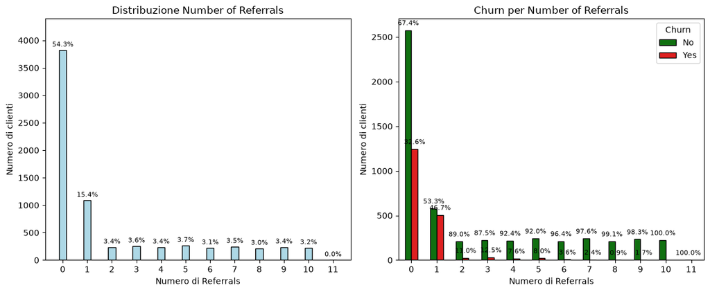

```python
count_per_type = merged_df['Number of Referrals'].value_counts().sort_index()
total_left = count_per_type.sum()
max_left = count_per_type.max()

palette = {'Yes': 'red', 'No': 'green'}

fig, axes = plt.subplots(1, 2, figsize=(12, 5))

x_left = range(len(count_per_type))
axes[0].bar(
    x_left,
    count_per_type.values,
    width=0.3,
    color=['lightblue'],
    edgecolor='black'
)
axes[0].set_xticks(x_left)
axes[0].set_xticklabels(count_per_type.index.astype(str), rotation=0)
axes[0].set_title('Distribuzione Number of Referrals')
axes[0].set_xlabel('Numero di Referrals')
axes[0].set_ylabel('Numero di clienti')
axes[0].set_ylim(0, max_left * 1.15)

for i, v in enumerate(count_per_type.values):
    axes[0].text(
        i,
        v + max_left * 0.01,
        f'{(v/total_left)*100:.1f}%',
        ha='center', va='bottom', fontsize=8
    )

ax = axes[1]
sns.countplot(
    data=merged_df,
    x='Number of Referrals',
    hue='Churn',
    palette=palette,
    edgecolor='black',
    width=0.5,
    ax=ax
)
ax.set_title('Churn per Number of Referrals')
ax.set_xlabel('Numero di Referrals')
ax.set_ylabel('Numero di clienti')
ax.legend(title='Churn', loc='upper right')

counts = merged_df['Number of Referrals'].value_counts().sort_index()
categories = counts.index.tolist()
n_hue = merged_df['Churn'].nunique()
y_max = counts.max()

churn_totals = merged_df.groupby(['Number of Referrals', 'Churn']).size().unstack().fillna(0)
category_totals = churn_totals.sum(axis=1)
y_max = category_totals.max()
x_labels = [tick.get_text() for tick in ax.get_xticklabels()]

for j, container in enumerate(ax.containers):
    for i, bar in enumerate(container):
        height = bar.get_height()
        if height == 0:
            continue
        category = int(x_labels[i])
        total = category_totals[category]
        perc = (height / total) * 100

        ax.text(
            bar.get_x() + bar.get_width() / 2,
            height + y_max * 0.01,
            f'{perc:.1f}%',
            ha='center',
            va='bottom',
            fontsize=8
        )

plt.tight_layout()
plt.show()
```

## **Attributi relativi al piano tariffario**

A questo punto, risulta utile analizzare gli attributi correlati a piani tariffari in relazione al Churn.

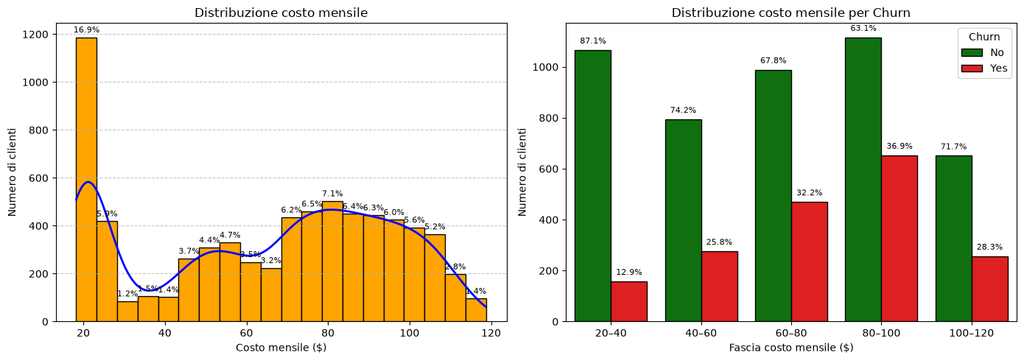

```python
palette = {'Yes': 'red', 'No': 'green'}

bin_edges = [20, 40, 60, 80, 100, 120]
bin_labels = [f'{bin_edges[i]}–{bin_edges[i+1]}' for i in range(len(bin_edges)-1)]

merged_df['ChargeBin'] = pd.cut(
    merged_df['Monthly Charge'],
    bins=bin_edges,
    labels=bin_labels,
    include_lowest=True,
    right=False
)

fig, axes = plt.subplots(1, 2, figsize=(14, 5))

x = merged_df['Monthly Charge'].dropna().astype(float).values

n_bins = 20
counts, bins, patches = axes[0].hist(
    x,
    bins=n_bins,
    color='orange',
    edgecolor='black',
)

kde = gaussian_kde(x)

x_grid = np.linspace(bins.min(), bins.max(), 200)
dens = kde(x_grid)

bin_width = bins[1] - bins[0]
scaled_kde = dens * len(x) * bin_width

axes[0].plot(
    x_grid,
    scaled_kde,
    color='blue',
    linewidth=2
)

axes[0].set_title('Distribuzione costo mensile')
axes[0].set_xlabel('Costo mensile ($)')
axes[0].set_ylabel('Numero di clienti')
axes[0].grid(axis='y', linestyle='--', alpha=0.7)

axes[0].set_xticks([20, 40, 60, 80, 100, 120])
axes[0].set_xticklabels([str(t) for t in [20, 40, 60, 80, 100, 120]])

total_count = counts.sum()
for cnt, bar in zip(counts, patches):
    if cnt > 0:
        x_mid = bar.get_x() + bar.get_width() / 2
        pct = cnt / total_count * 100
        axes[0].text(
            x_mid,
            cnt + counts.max() * 0.01,
            f'{pct:.1f}%',
            ha='center',
            va='bottom',
            fontsize=8
        )

ax = axes[1]
sns.countplot(
    data=merged_df,
    x='ChargeBin',
    hue='Churn',
    palette=palette,
    edgecolor='black',
    ax=ax
)

ax.set_title('Distribuzione costo mensile per Churn')
ax.set_xlabel('Fascia costo mensile ($)')
ax.set_ylabel('Numero di clienti')
ax.legend(title='Churn', loc='upper right')

churn_ct = merged_df.groupby(['ChargeBin', 'Churn'], observed=False).size().unstack(fill_value=0)
bin_totals = churn_ct.sum(axis=1)
y_max = bin_totals.max()

for container in ax.containers:
    for bar in container:
        h = bar.get_height()
        if h == 0:
            continue
        bin_idx = int(bar.get_x() + bar.get_width()/2 + 0.5)
        if bin_idx < len(bin_totals):
            total = bin_totals.iloc[bin_idx]
            pct = h / total * 100
            ax.text(
                bar.get_x() + bar.get_width()/2,
                h + y_max * 0.01,
                f'{pct:.1f}%',
                ha='center',
                va='bottom',
                fontsize=8
            )

plt.tight_layout()
plt.show()
merged_df = merged_df.drop(columns=['ChargeBin'])
```

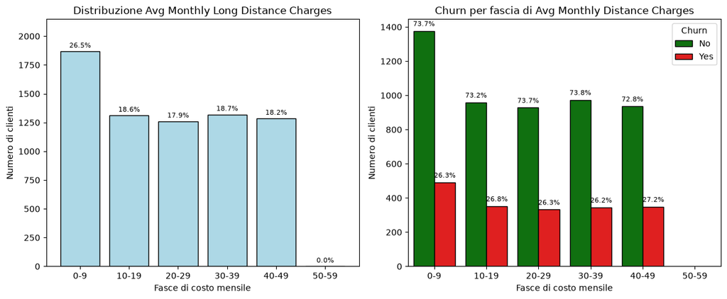

```python
palette = {'Yes': 'red', 'No': 'green'}
bins = [0, 10, 20, 30, 40, 50, 60]
labels = ['0-9', '10-19', '20-29', '30-39', '40-49', '50-59']
merged_df['Charges Bin'] = pd.cut(merged_df['Avg Monthly Long Distance Charges'], bins=bins, labels=labels, right=False)

fig, axes = plt.subplots(1, 2, figsize=(12, 5))

charges_counts = merged_df['Charges Bin'].value_counts().sort_index()
bars = axes[0].bar(
    charges_counts.index,
    charges_counts.values,
    color='lightblue',
    edgecolor='black'
)

axes[0].set_title('Distribuzione Avg Monthly Long Distance Charges')
axes[0].set_xlabel('Fasce di costo mensile')
axes[0].set_ylabel('Numero di clienti')
axes[0].set_ylim(0, charges_counts.max() * 1.15)

total_charges = charges_counts.sum()
for bar in bars:
    height = bar.get_height()
    pct = height / total_charges * 100
    axes[0].text(
        bar.get_x() + bar.get_width() / 2,
        height + charges_counts.max()*0.01,
        f'{pct:.1f}%',
        ha='center',
        va='bottom',
        fontsize=8
    )

ax = axes[1]
sns.countplot(
    data=merged_df,
    x='Charges Bin',
    hue='Churn',
    palette=palette,
    edgecolor='black',
    ax=ax
)

ax.set_title('Churn per fascia di Avg Monthly Distance Charges')
ax.set_xlabel('Fasce di costo mensile')
ax.set_ylabel('Numero di clienti')
ax.legend(title='Churn', loc='upper right')

ct = merged_df.groupby(['Charges Bin', 'Churn'], observed=False).size().unstack(fill_value=0).reindex(index=labels)
totals = ct.sum(axis=1)
y_max = totals.max()

for container in ax.containers:
    for bar in container:
        h = bar.get_height()
        if h == 0:
            continue
        x_label = bar.get_x() + bar.get_width()/2
        idx = int(round(x_label))  # x positions align to bin index
        charge_bin = labels[idx] if idx < len(labels) else None
        if charge_bin is None:
            continue
        total = totals.loc[charge_bin]
        pct = h / total * 100
        ax.text(
            bar.get_x() + bar.get_width()/2,
            h + y_max * 0.01,
            f'{pct:.1f}%',
            ha='center',
            va='bottom',
            fontsize=8
        )

plt.tight_layout()
plt.show()
merged_df = merged_df.drop(columns=['Charges Bin'])
```

Questo valore non risulta essere particolarmente informativo: la distribuzione di clienti che fa churn si attesta circa sul 27% per ciascuna fascia di prezzo.

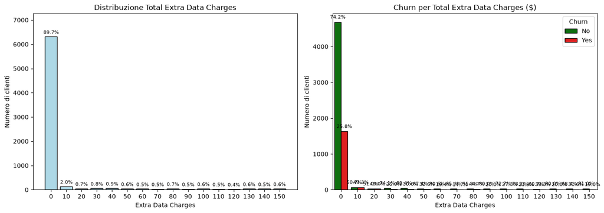

```python
palette = {'Yes': 'red', 'No': 'green'}

# 1) Preparo l'attributo come categoria ordinata
vals = sorted(merged_df['Total Extra Data Charges'].unique())
labels = [str(v) for v in vals]
merged_df['Extra_Charges_Cat'] = merged_df['Total Extra Data Charges'].astype(str)

fig, axes = plt.subplots(1, 2, figsize=(14, 5))

# === SINISTRA: distribuzione totale ===
counts = merged_df['Extra_Charges_Cat'] \
    .value_counts() \
    .reindex(labels, fill_value=0)

bars = axes[0].bar(
    counts.index,
    counts.values,
    color='lightblue',
    edgecolor='black'
)

axes[0].set_title('Distribuzione Total Extra Data Charges')
axes[0].set_xlabel('Extra Data Charges')
axes[0].set_ylabel('Numero di clienti')
axes[0].set_ylim(0, counts.max() * 1.15)

total = counts.sum()
for bar in bars:
    h = bar.get_height()
    if h == 0:
        continue
    pct = h / total * 100
    axes[0].text(
        bar.get_x() + bar.get_width() / 2,
        h + counts.max() * 0.01,
        f'{pct:.1f}%',
        ha='center',
        va='bottom',
        fontsize=8
    )

# === DESTRA: churn per valore ===
ax = axes[1]
sns.countplot(
    data=merged_df,
    x='Extra_Charges_Cat',
    hue='Churn',
    order=labels,
    hue_order=['No','Yes'],
    palette=palette,
    edgecolor='black',
    ax=ax
)

ax.set_title('Churn per Total Extra Data Charges ($)')
ax.set_xlabel('Extra Data Charges')
ax.set_ylabel('Numero di clienti')
ax.legend(title='Churn', loc='upper right')

y_max = counts.max()

for container in ax.containers:
    for i, bar in enumerate(container):
        h = bar.get_height()
        if h == 0:
            continue
        service = labels[i]
        total_i = counts.loc[service]
        pct = h / total_i * 100

        ax.text(
            bar.get_x() + bar.get_width() / 2,
            h + y_max * 0.01,
            f'{pct:.1f}%',
            ha='center',
            va='bottom',
            fontsize=8
        )

plt.tight_layout()
plt.show()
merged_df = merged_df.drop(columns=['Extra_Charges_Cat'])
```

L'attributo Total Extra Data Charges non risulta particolarmente informativo: la percentuale di clienti che acquistano un pacchetto dati aggiuntivo è troppo ridotta rispetto a quelli che non lo fanno. Di conseguenza, decidiamo di escludere questo attributo dal dataset. Verifichiamo ora quanto eventuali rimborsi influiscano sul Churn.

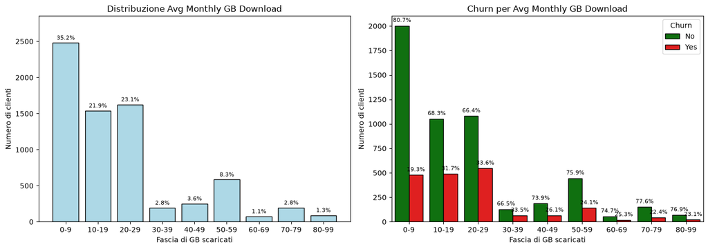

```python
palette = {'Yes': 'red', 'No': 'green'}

bins = [0, 10, 20, 30, 40, 50, 60, 70, 80, float('inf')]
labels = ['0-9', '10-19', '20-29', '30-39', '40-49',
          '50-59', '60-69', '70-79', '80-99']

merged_df['GB_Download_Range'] = pd.cut(
    merged_df['Avg Monthly GB Download'],
    bins=bins,
    labels=labels,
    right=False
)

fig, axes = plt.subplots(1, 2, figsize=(14, 5))

download_counts = merged_df['GB_Download_Range'] \
    .value_counts() \
    .reindex(labels, fill_value=0)

bars = axes[0].bar(
    download_counts.index,
    download_counts.values,
    color='lightblue',
    edgecolor='black'
)

axes[0].set_title('Distribuzione Avg Monthly GB Download')
axes[0].set_xlabel('Fascia di GB scaricati')
axes[0].set_ylabel('Numero di clienti')
axes[0].set_ylim(0, download_counts.max() * 1.15)

total_downloads = download_counts.sum()
for bar in bars:
    height = bar.get_height()
    pct = height / total_downloads * 100
    axes[0].text(
        bar.get_x() + bar.get_width() / 2,
        height + download_counts.max() * 0.01,
        f'{pct:.1f}%',
        ha='center',
        va='bottom',
        fontsize=8
    )

ax = axes[1]
sns.countplot(
    data=merged_df,
    x='GB_Download_Range',
    hue='Churn',
    order=labels,
    hue_order=['No','Yes'],
    palette=palette,
    edgecolor='black',
    ax=ax
)

ax.set_title('Churn per Avg Monthly GB Download')
ax.set_xlabel('Fascia di GB scaricati')
ax.set_ylabel('Numero di clienti')
ax.legend(title='Churn', loc='upper right')

y_max = download_counts.max()

for j, container in enumerate(ax.containers):
    for i, bar in enumerate(container):
        height = bar.get_height()
        if height == 0:
            continue

        service = labels[i]
        relativeTotal = download_counts[service]
        pct = height / relativeTotal * 100

        ax.text(
            bar.get_x() + bar.get_width() / 2,
            height + y_max * 0.01,
            f'{pct:.1f}%',
            ha='center',
            va='bottom',
            fontsize=8
        )

plt.tight_layout()
plt.show()
merged_df = merged_df.drop(columns=['GB_Download_Range'])
```

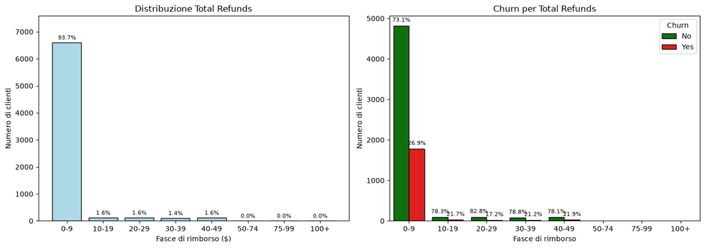

```python
palette = {'Yes': 'red', 'No': 'green'}

bins = [0, 10, 20, 30, 40, 50, 75, 100, float('inf')]
labels = ['0-9', '10-19', '20-29', '30-39', '40-49', '50-74', '75-99', '100+']

merged_df['Refunds_Range'] = pd.cut(
    merged_df['Total Refunds'],
    bins=bins,
    labels=labels,
    right=False
)

fig, axes = plt.subplots(1, 2, figsize=(14, 5))

download_counts = (
    merged_df['Refunds_Range']
    .value_counts()
    .reindex(labels, fill_value=0)
)

bars = axes[0].bar(
    download_counts.index,
    download_counts.values,
    color='lightblue',
    edgecolor='black'
)
axes[0].set_title('Distribuzione Total Refunds')
axes[0].set_xlabel('Fasce di rimborso ($)')
axes[0].set_ylabel('Numero di clienti')
axes[0].set_ylim(0, download_counts.max() * 1.15)

total_refunds = download_counts.sum()
for bar in bars:
    h = bar.get_height()
    pct = h / total_refunds * 100
    axes[0].text(
        bar.get_x() + bar.get_width()/2,
        h + download_counts.max()*0.01,
        f'{pct:.1f}%',
        ha='center', va='bottom',
        fontsize=8
    )

ax = axes[1]
sns.countplot(
    data=merged_df,
    x='Refunds_Range',
    hue='Churn',
    order=labels,
    hue_order=['No','Yes'],
    palette=palette,
    edgecolor='black',
    ax=ax
)
ax.set_title('Churn per Total Refunds')
ax.set_xlabel('Fasce di rimborso')
ax.set_ylabel('Numero di clienti')
ax.legend(title='Churn', loc='upper right')

y_max = download_counts.max()

for j, container in enumerate(ax.containers):
    for i, bar in enumerate(container):
        h = bar.get_height()
        if h == 0:
            continue
        service = labels[i]
        relativeTotal = download_counts[service]
        pct = h / relativeTotal * 100

        ax.text(
            bar.get_x() + bar.get_width()/2,
            h + y_max*0.01,
            f'{pct:.1f}%',
            ha='center', va='bottom',
            fontsize=8
        )

plt.tight_layout()
plt.show()
merged_df = merged_df.drop(columns=['Refunds_Range'])
```

Anche questo attributo risulta poco informativo ai fini della nostra analisi e, pertanto, non verrà considerato nella fase di classificazione.

Passiamo ora a esaminare l’influenza del Total Revenue.

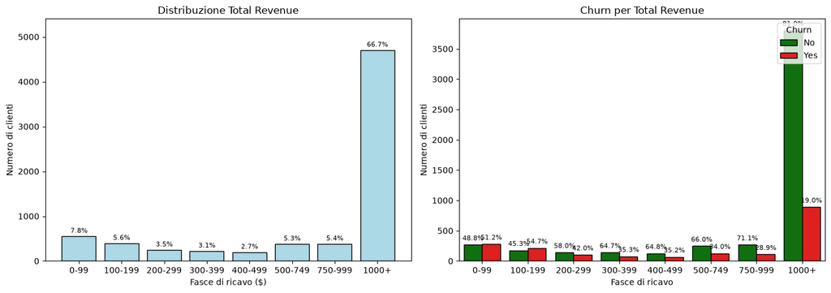

```python
palette = {'Yes': 'red', 'No': 'green'}

bins = [0, 100, 200, 300, 400, 500, 750, 1000, float('inf')]
labels = ['0-99', '100-199', '200-299', '300-399', '400-499', '500-749', '750-999', '1000+']

merged_df['Revenue_Range'] = pd.cut(
    merged_df['Total Revenue'],
    bins=bins,
    labels=labels,
    right=False
)

fig, axes = plt.subplots(1, 2, figsize=(14, 5))

revenue_counts = (
    merged_df['Revenue_Range']
    .value_counts()
    .reindex(labels, fill_value=0)
)

bars = axes[0].bar(
    revenue_counts.index,
    revenue_counts.values,
    color='lightblue',
    edgecolor='black'
)
axes[0].set_title('Distribuzione Total Revenue')
axes[0].set_xlabel('Fasce di ricavo ($)')
axes[0].set_ylabel('Numero di clienti')
axes[0].set_ylim(0, revenue_counts.max() * 1.15)

total_revenue_count = revenue_counts.sum()
for bar in bars:
    h = bar.get_height()
    pct = h / total_revenue_count * 100
    axes[0].text(
        bar.get_x() + bar.get_width()/2,
        h + revenue_counts.max()*0.01,
        f'{pct:.1f}%',
        ha='center', va='bottom',
        fontsize=8
    )

ax = axes[1]
sns.countplot(
    data=merged_df,
    x='Revenue_Range',
    hue='Churn',
    order=labels,
    hue_order=['No', 'Yes'],
    palette=palette,
    edgecolor='black',
    ax=ax
)
ax.set_title('Churn per Total Revenue')
ax.set_xlabel('Fasce di ricavo')
ax.set_ylabel('Numero di clienti')
ax.legend(title='Churn', loc='upper right')

y_max = revenue_counts.max()

for j, container in enumerate(ax.containers):
    for i, bar in enumerate(container):
        h = bar.get_height()
        if h == 0 or i >= len(labels):
            continue
        revenue_range = labels[i]
        relative_total = revenue_counts[revenue_range]
        pct = h / relative_total * 100 if relative_total > 0 else 0

        ax.text(
            bar.get_x() + bar.get_width()/2,
            h + y_max*0.01,
            f'{pct:.1f}%',
            ha='center', va='bottom',
            fontsize=8
        )

plt.tight_layout()
plt.show()
merged_df = merged_df.drop(columns=['Revenue_Range'])
```

La maggior parte dei clienti (66,7%) appartiene alla fascia di ricavo superiore a 1000 dollari. Tuttavia, osservando la distribuzione del Churn, notiamo che proprio in questa fascia il tasso di abbandono è relativamente basso (19%), rispetto alle fasce intermedie, dove supera spesso il 30-40%. Questo suggerisce che i clienti con ricavi più elevati tendono a essere più fidelizzati. Per questo motivo, l'attributo Total Revenue sarà da considerare nella classificazione.

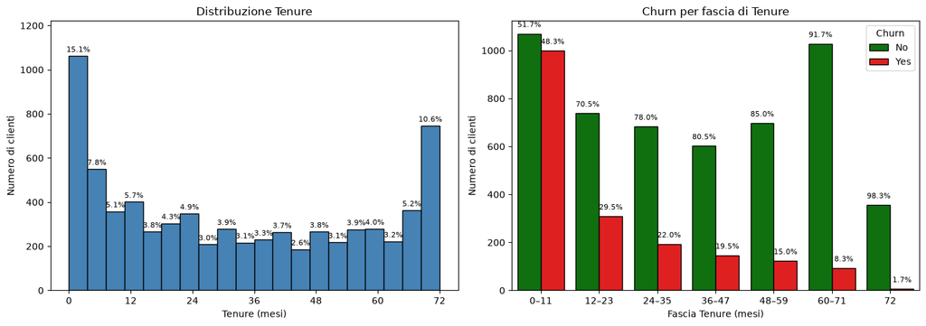

```python
fig, axes = plt.subplots(1, 2, figsize=(14, 5))

n_bins = 20
tenure_vals = merged_df['Tenure']

counts, bins, patches = axes[0].hist(
    tenure_vals,
    bins=n_bins,
    color='steelblue',
    edgecolor='black'
)

tick_vals = list(range(0, 73, 12))
axes[0].set_xticks(tick_vals)
axes[0].set_xticklabels([str(v) for v in tick_vals])

axes[0].set_title('Distribuzione Tenure')
axes[0].set_xlabel('Tenure (mesi)')
axes[0].set_ylabel('Numero di clienti')
axes[0].set_ylim(0, counts.max() * 1.15)

total_all = counts.sum()
for bar, cnt in zip(patches, counts):
    if cnt > 0:
        pct = cnt / total_all * 100
        x = bar.get_x() + bar.get_width()/2
        axes[0].text(
            x,
            cnt + counts.max()*0.01,
            f'{pct:.1f}%',
            ha='center', va='bottom', fontsize=8
        )

tenure_edges = [0, 12, 24, 36, 48, 60, 72, np.inf]
tenure_labels = ['0–11','12–23','24–35','36–47','48–59','60–71','72']
merged_df['TenureBin'] = pd.cut(
    merged_df['Tenure'],
    bins=tenure_edges,
    labels=tenure_labels,
    include_lowest=True,
    right=False
)

ax = axes[1]
sns.countplot(
    data=merged_df,
    x='TenureBin',
    hue='Churn',
    palette=palette,
    edgecolor='black',
    ax=ax
)

ax.set_title('Churn per fascia di Tenure')
ax.set_xlabel('Fascia Tenure (mesi)')
ax.set_ylabel('Numero di clienti')
ax.legend(title='Churn', loc='upper right')

ct = merged_df.groupby(['TenureBin','Churn'], observed=False).size().unstack(fill_value=0)
bin_totals = ct.sum(axis=1)
y_max = bin_totals.max()

for container in ax.containers:
    for bar in container:
        h = bar.get_height()
        if h == 0:
            continue
        idx = int(round(bar.get_x() + bar.get_width()/2))
        total = bin_totals.iloc[idx]
        pct = h / total * 100
        ax.text(
            bar.get_x() + bar.get_width()/2,
            h + y_max*0.01,
            f'{pct:.1f}%',
            ha='center', va='bottom', fontsize=8
        )

plt.tight_layout()
plt.show()
merged_df = merged_df.drop(columns=['TenureBin'])
```

Possiamo osservare dal grafico come i clienti che hanno un valore di permanenza maggiore tendono a disdire di meno. Questo attributo risulta fondamentale nella nostra analisi.

Verifichiamo se la tipologia del contratto influisce sul Churn:

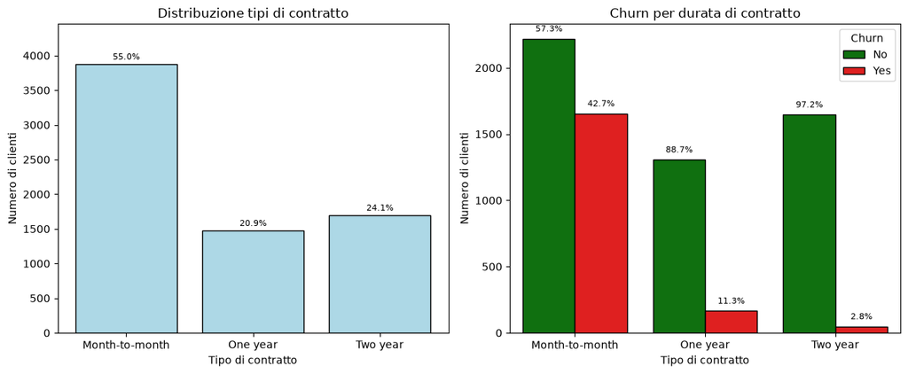

```python
palette = {'Yes': 'red', 'No': 'green'}

contract_order = ['Month-to-month', 'One year', 'Two year']

fig, axes = plt.subplots(1, 2, figsize=(12, 5))

contract_counts = merged_df['Contract'].value_counts().reindex(contract_order)

bars = axes[0].bar(
    contract_counts.index,
    contract_counts.values,
    color='lightblue',
    edgecolor='black'
)

axes[0].set_title('Distribuzione tipi di contratto')
axes[0].set_xlabel('Tipo di contratto')
axes[0].set_ylabel('Numero di clienti')
axes[0].set_ylim(0, contract_counts.max() * 1.15)

total_contracts = contract_counts.sum()
for bar in bars:
    height = bar.get_height()
    pct = height / total_contracts * 100
    axes[0].text(
        bar.get_x() + bar.get_width() / 2,
        height + contract_counts.max()*0.01,
        f'{pct:.1f}%',
        ha='center',
        va='bottom',
        fontsize=8
    )

ax = axes[1]
sns.countplot(
    data=merged_df,
    x='Contract',
    hue='Churn',
    palette=palette,
    order=contract_order,
    edgecolor='black',
    ax=ax
)

ax.set_title('Churn per durata di contratto')
ax.set_xlabel('Tipo di contratto')
ax.set_ylabel('Numero di clienti')
ax.legend(title='Churn', loc='upper right')

ct = merged_df.groupby(['Contract', 'Churn'], observed=False).size().unstack(fill_value=0).reindex(index=contract_order)
totals = ct.sum(axis=1)
y_max = totals.max()

for container in ax.containers:
    for bar in container:
        h = bar.get_height()
        if h == 0:
            continue
        contract_label = bar.get_x() + bar.get_width()/2
        idx = int(round(contract_label))  # posizione dell’etichetta
        contract = contract_order[idx]
        total = totals.loc[contract]
        pct = h / total * 100
        ax.text(
            bar.get_x() + bar.get_width()/2,
            h + y_max * 0.01,
            f'{pct:.1f}%',
            ha='center',
            va='bottom',
            fontsize=8
        )

plt.tight_layout()
plt.show()
```

Anche questo attributo risulta particolarmente informativo: è possibile osservare che i clienti maggiormente coinvolti nel Churn sono gli stessi che sottoscrivono contratti mensili.

Valutiamo ora se la feature Paperless Billing possa influenzare il Churn.

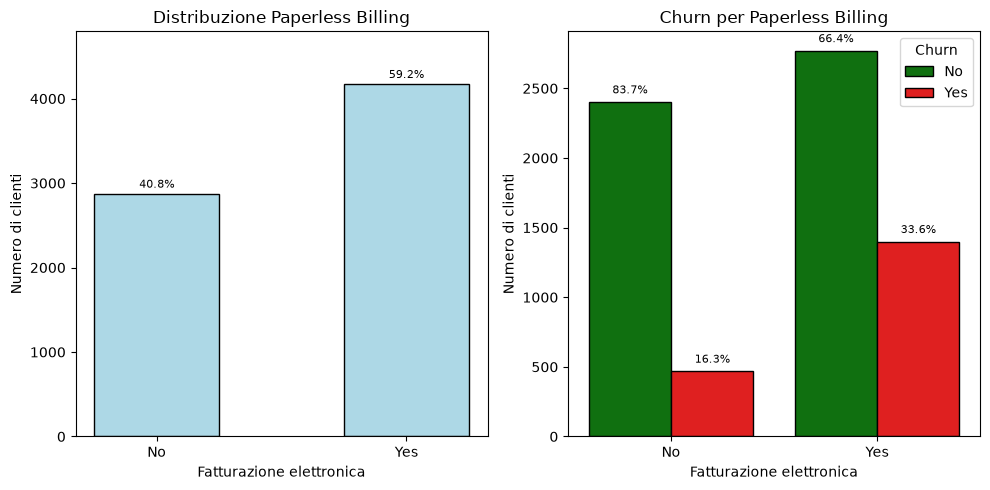

```python
palette = {'Yes': 'red', 'No': 'green'}
billing_order = ['No', 'Yes']
fig, axes = plt.subplots(1, 2, figsize=(10, 5))

billing_counts = merged_df['Paperless Billing'].value_counts().reindex(billing_order)

bars = axes[0].bar(
    billing_counts.index,
    billing_counts.values,
    width=0.5,
    color='lightblue',
    edgecolor='black'
)

axes[0].set_title('Distribuzione Paperless Billing')
axes[0].set_xlabel('Fatturazione elettronica')
axes[0].set_ylabel('Numero di clienti')
axes[0].set_ylim(0, billing_counts.max() * 1.15)

total_billing = billing_counts.sum()
for bar in bars:
    height = bar.get_height()
    pct = height / total_billing * 100
    axes[0].text(
        bar.get_x() + bar.get_width() / 2,
        height + billing_counts.max() * 0.01,
        f'{pct:.1f}%',
        ha='center',
        va='bottom',
        fontsize=8
    )

ax = axes[1]
sns.countplot(
    data=merged_df,
    x='Paperless Billing',
    hue='Churn',
    palette=palette,
    order=billing_order,
    edgecolor='black',
    ax=ax
)

ax.set_title('Churn per Paperless Billing')
ax.set_xlabel('Fatturazione elettronica')
ax.set_ylabel('Numero di clienti')
ax.legend(title='Churn', loc='upper right')

ct = merged_df.groupby(['Paperless Billing', 'Churn'], observed=False).size().unstack(fill_value=0).reindex(index=billing_order)
totals = ct.sum(axis=1)
y_max = totals.max()

for container in ax.containers:
    for bar in container:
        h = bar.get_height()
        if h == 0:
            continue
        label_pos = bar.get_x() + bar.get_width() / 2
        idx = int(round(label_pos))
        billing_label = billing_order[idx]
        total = totals.loc[billing_label]
        pct = h / total * 100
        ax.text(
            bar.get_x() + bar.get_width() / 2,
            h + y_max * 0.01,
            f'{pct:.1f}%',
            ha='center',
            va='bottom',
            fontsize=8
        )

plt.tight_layout()
plt.show()
```

Questo attributo sembrerebbe essere una delle maggiori cause di Churn: supponiamo che la ricezione di una bolletta elettronica possa condizionare il cliente.

Analizziamo adesso l'influenza del metodo di pagamento sul Churn.

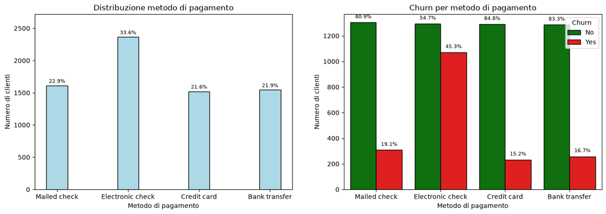

```python
palette_churn = {'Yes': 'red', 'No': 'green'}

payment_order = [
    'Mailed check',
    'Electronic check',
    'Credit card (automatic)',
    'Bank transfer (automatic)'
]

fig, axes = plt.subplots(1, 2, figsize=(16, 5))

payment_counts = merged_df['Payment Method'].value_counts().reindex(payment_order)

bars = axes[0].bar(
    payment_counts.index,
    payment_counts.values,
    width=0.3,
    color='lightblue',
    edgecolor='black'
)

axes[0].set_title('Distribuzione metodo di pagamento')
axes[0].set_xlabel('Metodo di pagamento')
axes[0].set_ylabel('Numero di clienti')
axes[0].set_ylim(0, payment_counts.max() * 1.15)
axes[0].tick_params(axis='x', rotation=0)

total_payment = payment_counts.sum()
for bar in bars:
    height = bar.get_height()
    pct = height / total_payment * 100
    axes[0].text(
        bar.get_x() + bar.get_width() / 2,
        height + payment_counts.max() * 0.01,
        f'{pct:.1f}%',
        ha='center',
        va='bottom',
        fontsize=8
    )

ax = axes[1]
sns.countplot(
    data=merged_df,
    x='Payment Method',
    hue='Churn',
    palette=palette_churn,
    order=payment_order,
    edgecolor='black',
    ax=ax
)

ax.set_title('Churn per metodo di pagamento')
ax.set_xlabel('Metodo di pagamento')
ax.set_ylabel('Numero di clienti')
ax.legend(title='Churn', loc='upper right')
ax.tick_params(axis='x', rotation=0)

ct = merged_df.groupby(['Payment Method', 'Churn'], observed=False).size().unstack(fill_value=0).reindex(index=payment_order)
totals = ct.sum(axis=1)
y_max = totals.max()

for container in ax.containers:
    for bar in container:
        h = bar.get_height()
        if h == 0:
            continue
        label_pos = bar.get_x() + bar.get_width() / 2
        idx = int(round(label_pos))
        if idx >= len(payment_order):
            continue
        payment_label = payment_order[idx]
        total = totals.loc[payment_label]
        pct = h / total * 100
        ax.text(
            bar.get_x() + bar.get_width() / 2,
            h + y_max * 0.01,
            f'{pct:.1f}%',
            ha='center',
            va='bottom',
            fontsize=8
        )

for ax in axes:
    new_labels = [re.sub(r'\s*\(.*?\)', '', label.get_text()) for label in ax.get_xticklabels()]
    ax.set_xticks(range(len(new_labels)))
    ax.set_xticklabels(new_labels)

plt.show()
```

Il grafico mostra come i clienti che adottano un sistema di pagamento elettronico tendano a disdire maggiormente il contratto attivo. Pertanto, l'attributo in esame sarà considerato durante la classificazione.

Analizziamo dunque, l'attributo relativo al ciclo di vita dei clienti.

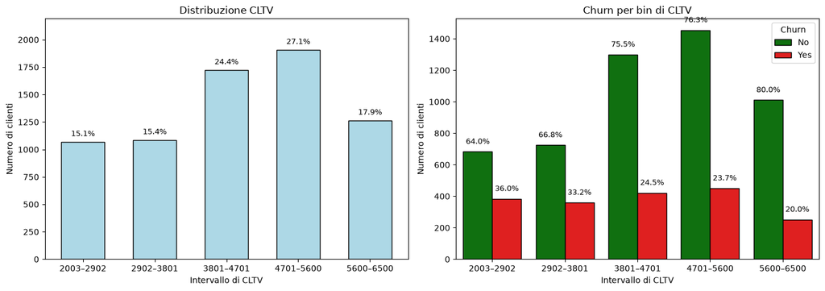

```python
cltv_min = merged_df['CLTV'].min()
cltv_max = merged_df['CLTV'].max()

n_bins = 5
bin_edges = np.linspace(cltv_min, cltv_max, n_bins + 1)

labels = []
for i in range(n_bins):
    left = int(bin_edges[i])
    right = int(bin_edges[i+1])
    labels.append(f"{left}–{right}")

merged_df['CLTV_bin'] = pd.cut(
    merged_df['CLTV'],
    bins=bin_edges,
    labels=labels,
    include_lowest=True,
    right=True
)

cltv_counts = merged_df['CLTV_bin'].value_counts().reindex(labels)
total = cltv_counts.sum()

palette_churn = {'Yes': 'red', 'No': 'green'}

fig, axes = plt.subplots(1, 2, figsize=(14, 5))

bars = axes[0].bar(
    cltv_counts.index,
    cltv_counts.values,
    width=0.6,
    color='lightblue',
    edgecolor='black'
)

axes[0].set_title('Distribuzione CLTV')
axes[0].set_xlabel('Intervallo di CLTV')
axes[0].set_ylabel('Numero di clienti')
axes[0].set_ylim(0, cltv_counts.max() * 1.15)
axes[0].tick_params(axis='x', rotation=0)

for bar in bars:
    height = bar.get_height()
    pct = height / total * 100
    axes[0].text(
        bar.get_x() + bar.get_width() / 2,
        height + cltv_counts.max() * 0.02,
        f'{pct:.1f}%',
        ha='center',
        va='bottom',
        fontsize=9
    )

ax = axes[1]

sns.countplot(
    data=merged_df,
    x='CLTV_bin',
    hue='Churn',
    palette=palette_churn,
    order=labels,
    edgecolor='black',
    ax=ax
)

ax.set_title('Churn per bin di CLTV')
ax.set_xlabel('Intervallo di CLTV')
ax.set_ylabel('Numero di clienti')
ax.legend(title='Churn', loc='upper right')
ax.tick_params(axis='x', rotation=0)

ct = (
    merged_df
    .groupby(['CLTV_bin', 'Churn'], observed=False)
    .size()
    .unstack(fill_value=0)
    .reindex(index=labels)
)

totals_by_bin = ct.sum(axis=1)
y_max = totals_by_bin.max()

for container in ax.containers:
    for bar in container:
        h = bar.get_height()
        if h == 0:
            continue
        bin_idx = int(np.round(bar.get_x() + bar.get_width() / 2))
        if bin_idx >= len(labels):
            continue
        bin_label = labels[bin_idx]
        total_bin = totals_by_bin.loc[bin_label]
        pct = h / total_bin * 100
        ax.text(
            bar.get_x() + bar.get_width() / 2,
            h + y_max * 0.02,
            f'{pct:.1f}%',
            ha='center',
            va='bottom',
            fontsize=9
        )

plt.tight_layout()
plt.show()
merged_df = merged_df.drop(columns=['CLTV_bin'])
```

Il grafico mostra che a valori più alti di CLTV corrisponde un Churn decrescente. L'attributo risulta dunque, significativo per la nostra analisi.

Visualizziamo anche l'attributo Offer. Secondo la descrizione dell’attributo fornita sul sito da cui è stato scaricato il dataset, la colonna dovrebbe contenere i valori: None, Offer A, Offer B, Offer C, Offer D e Offer E. Tuttavia, analizzando i dati, si osserva che i valori None sono assenti e al loro posto compaiono valori NaN. Per uniformare la codifica e semplificare l’analisi, sostituiamo tutti i NaN con il valore "No", che rappresenta l’assenza di un’offerta attiva.

```python
print(merged_df['Offer'].unique())
merged_df['Offer'] = merged_df['Offer'].fillna('No')
print(merged_df['Offer'].unique())
```

```
<StringArray>
[nan, 'Offer E', 'Offer D', 'Offer A', 'Offer B', 'Offer C']
Length: 6, dtype: str
<StringArray>
['No', 'Offer E', 'Offer D', 'Offer A', 'Offer B', 'Offer C']
Length: 6, dtype: str
```

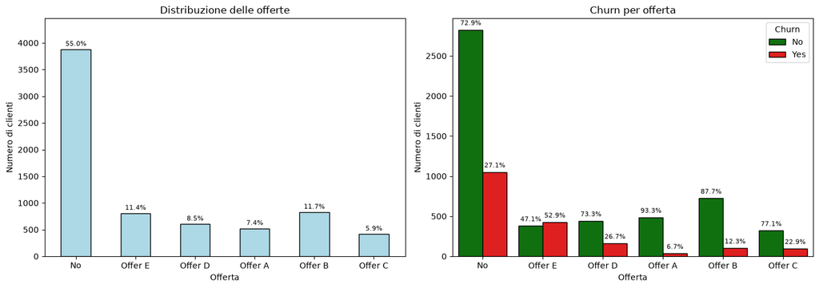

```python
offer_order = ['No', 'Offer E', 'Offer D', 'Offer A', 'Offer B', 'Offer C']

offer_counts = merged_df['Offer'].value_counts().reindex(offer_order)
total_offers = offer_counts.sum()

palette_churn = {'Yes': 'red', 'No': 'green'}

fig, axes = plt.subplots(1, 2, figsize=(14, 5))

bars_left = axes[0].bar(
    offer_counts.index,
    offer_counts.values,
    width=0.5,
    color='lightblue',
    edgecolor='black'
)

axes[0].set_title('Distribuzione delle offerte')
axes[0].set_xlabel('Offerta')
axes[0].set_ylabel('Numero di clienti')
axes[0].set_ylim(0, offer_counts.max() * 1.15)
axes[0].tick_params(axis='x', rotation=0)

for bar in bars_left:
    height = bar.get_height()
    pct = height / total_offers * 100
    axes[0].text(
        bar.get_x() + bar.get_width() / 2,
        height + offer_counts.max() * 0.01,
        f'{pct:.1f}%',
        ha='center',
        va='bottom',
        fontsize=8
    )

ax = axes[1]

sns.countplot(
    data=merged_df,
    x='Offer',
    hue='Churn',
    palette=palette_churn,
    order=offer_order,
    edgecolor='black',
    ax=ax
)

ax.set_title('Churn per offerta')
ax.set_xlabel('Offerta')
ax.set_ylabel('Numero di clienti')
ax.legend(title='Churn', loc='upper right')
ax.tick_params(axis='x', rotation=0)

ct = (
    merged_df
    .groupby(['Offer', 'Churn'], observed=False)
    .size()
    .unstack(fill_value=0)
    .reindex(index=offer_order)
)

totals_by_offer = ct.sum(axis=1)
y_max = totals_by_offer.max()

for container in ax.containers:
    for bar in container:
        h = bar.get_height()
        if h == 0:
            continue
        bin_idx = int(round(bar.get_x() + bar.get_width() / 2))
        if bin_idx >= len(offer_order):
            continue
        offer_label = offer_order[bin_idx]
        total_offer = totals_by_offer.loc[offer_label]
        pct = h / total_offer * 100
        ax.text(
            bar.get_x() + bar.get_width() / 2,
            h + y_max * 0.01,
            f'{pct:.1f}%',
            ha='center',
            va='bottom',
            fontsize=8
        )

for ax in axes:
    new_labels = [re.sub(r'\s*\(.*?\)', '', lbl.get_text()) for lbl in ax.get_xticklabels()]
    ax.set_xticks(range(len(new_labels)))
    ax.set_xticklabels(new_labels)

plt.tight_layout()
plt.show()
```

Ossreviamo che il valore del Churn in corrispondenza del valore Offer E tende ad essere molto maggiore rispetto alle altre offerte. L'attributo risulta pertanto, significativo e sarà considerato nell'analisi.